# Final Project Quantative Methods in Plant ecology

# 1 Research Interest:

The Interest of this work lays in reproducing the analysis and the corresponding graphical output from the ordinations shown in the paper: “The response of vegetation to chemical and hydrological gradients at a patterned rich fen in northern Alberta, Canada” published by [Vitt et al in 2022](https://www.sciencedirect.com/science/article/pii/S2214581822000519?via%3Dihub). Their research aimed at understanding the relationship between the chemical composition and level of the surficial water and the plant community patterns of a patterned rich fen in northern Alberta Canada. The hypotheses, results, and interpretations by Vitt et al (2022), linked to the ordinations, will be included. The ordinations were done using NMDS and the bray-curtis simillarity index. More than only reproducing this, different modeling options will be assessed. More explicitly the two following questions will be answered:

- 1. How do different modeling options like using a global or local model change the results?
- 2. is Bray-Curtis the most suitable index for the analysis or do alternative indices produce better results?

Finally since my interest is specifically into bryophytes I will explore ordinations using only bryophyte species for the community matrix and compare them to ordinations only using vascular species.

# 2 Hypothesis

The authors present two hypothesis:

- 1. Both hydrological and chemical gradients and plant communities have distinct spatial distributions across the fen
- 2. there are close linkages between hydrological and chemical gradients and plant communities and their distributions.

Although a large part of the analytical methods used in the research by Vitt et al. is not included in this work, the Ordinations and the environmental vectors are linked to both of these hypothesis and at least support them. The objective of the ordination analysis specifically is stated in the paper as “To determine if plant community changes occur across the fen”.

# 3 Packages

Let’s start with the reproduction of the analysis. First we need to load the necessary packages.

```r
install.load.package<-function(x){                      # Function by Erik Kusch*
if(!require(x,character.only=TRUE))                     # if x is a character and is not installed
install.packages(x,repos="http://cran.us.r-project.org")# install from R repository
require(x,character.only=TRUE)                          # load x
}                                                       # Package installation and loading
#* https://www.erikkusch.com/post/krigr-mats/krigrworkshop/

package_vec<- c(                                        # Package name character vector
  "knitr" ,                                             # R package required to compile R Markdown
  "data.table", "tidyverse",                            # Easy data management
  "vegan",                                              # ordinations, dissimilatry matrices etc.
  "reactable",                                          # creating reacting tables
  "goeveg",                                             # used for function dimcheck
  "MASS"   ,                                            # used for function IsoMDS
  "ggplot2" ,                                           # used for plotting
  "scales",                                             # scaling
  "patchwork",                                          # arranging ggplots
  "plyr"                                                # rounding function
  )
sapply(package_vec, install.load.package)               # run install.load.package on the vector
```

# 4 Data

The dataset of the research was kindly provided by the main author of the paper Dale H. Vitt, Distinguished University Scholar, Professor and Chair Emeritus, School of Biological Sciences, Plant Biology, Southern Illinois University. It was sent on the 12th January of 2023.

In their analysis Vitt et al. looked at the McClelland Wetland. The patterned area contained within the wetland is 6.6 km long, 2.5 km wide, and 720 ha in extent, with an elevational gradient from 300.4 to 292.8 m. They examined the easternmost portion of the patterned area of the wetland, within an area of approximately 420 ha (58% of the entire patterned area).The exact study site is located at 57º27′01.81′′ N, 111º25′35.90′′ W.

The area was divided into 64 plots and for each plot measurements were done at the nearest string and flark. 100 total species were recorded. The Species abundance was estimated for each string and flark as percent cover within a 2-meter diameter circular sampling plot. So each value gives the abundance of a species for the string or flark within a plot. Water chemistry as well as plant community patterns were recorded. The water samples were collected from the 20th to 28th of August, 2018 in a depth of 0 to 7 cm.

## 4.1 Community Dataset

The Community matrix should contain 128 columns, corresponding to 64 plots with two two records each (string and flark) and 100 rows corresponding to 100 recorded species.

### 4.1.1 Loading and structure

First we will read the community data from a csv file and take a look at the structure.

```r
# Read original community data
Com_Ori <- read.csv("fen_com_data.csv", header = T)

# Look at the structure of the Community data
str(Com_Ori)
```

```
## 'data.frame':    102 obs. of  129 variables:
##  $ X   : chr  "Vasular plants" "Andromeda polifolia" "Aster borealis" "Betula glandulifera" ...
##  $ X0S : chr  "Note: 2 veg surveys at each grid point: One in string (S) and one in flark (F)" "60" "0" "70" ...
##  $ X0F : int  NA 10 0 0 0 0 0 0 0 0 ...
##  $ X1S : int  NA 20 0 55 0 1 0 0 0 0 ...
##  $ X1F : int  NA 0 0 0 0 0 0 0 0 0 ...
##  $ X2S : int  NA 10 0 25 0 0 30 0 0 0 ...
##  $ X2F : int  NA 0 0 0 0 0 0 0 0 0 ...
##  $ X3S : int  NA 0 0 85 0 0 25 0 5 0 ...
##  $ X3F : int  NA 0 0 1 0 0 0 0 10 0 ...
##  $ X4S : int  NA 0 0 65 0 0 5 0 0 0 ...
##  $ X4F : int  NA 0 0 0 0 0 0 0 0 0 ...
##  $ X5S : int  NA 10 0 65 0 0 40 0 0 0 ...
##  $ X5F : int  NA 1 0 0 0 0 0 0 0 0 ...
##  $ X6S : int  NA 40 1 30 0 0 0 0 0 0 ...
```

[output cut: 86 more lines]

```r
# Creating reacting table with 600 pixel height
reactable(Com_Ori, height= 600)
```

| X | X0S | X0F | X1S | X1F | X2S | X2F | X3S | X3F | X4S | X4F | X5S | X5F | X6S | X6F | X7S | X7F | X8S | X8F | X9S | X9F | X10S | X10F | X11S | X11F | X12S | X12F | X13S | X13F | X14S | … |
| --- | --- | --- | --- | --- | --- | --- | --- | --- | --- | --- | --- | --- | --- | --- | --- | --- | --- | --- | --- | --- | --- | --- | --- | --- | --- | --- | --- | --- | --- | --- |
| Vasular plants | Note: 2 veg surveys at each grid point: One in string (S) and one in flark (F) | NA | NA | NA | NA | NA | NA | NA | NA | NA | NA | NA | NA | NA | NA | NA | NA | NA | NA | NA | NA | NA | NA | NA | NA | NA | NA | NA | NA | … |
| Andromeda polifolia | 60 | 10 | 20 | 0 | 10 | 0 | 0 | 0 | 0 | 0 | 10 | 1 | 40 | 0 | 5 | 0 | 5 | 0 | 20 | 0 | 5 | 0 | 5 | 0 | 5 | 0 | 5 | 0 | 35 | … |
| Aster borealis | 0 | 0 | 0 | 0 | 0 | 0 | 0 | 0 | 0 | 0 | 0 | 0 | 1 | 0 | 10 | 0 | 0 | 0 | 0 | 0 | 0 | 0 | 0 | 0 | 5 | 0 | 0 | 0 | 0 | … |
| Betula glandulifera | 70 | 0 | 55 | 0 | 25 | 0 | 85 | 1 | 65 | 0 | 65 | 0 | 30 | 0 | 65 | 0 | 35 | 0 | 1 | 30 | 30 | 10 | 40 | 25 | 40 | 0 | 40 | 0 | 70 | … |
| Calamagrostis canadensis | 0 | 0 | 0 | 0 | 0 | 0 | 0 | 0 | 0 | 0 | 0 | 0 | 0 | 0 | 0 | 0 | 0 | 0 | 0 | 0 | 0 | 0 | 0 | 0 | 0 | 0 | 0 | 0 | 0 | … |
| Calamagrostis inexpansa | 0 | 0 | 1 | 0 | 0 | 0 | 0 | 0 | 0 | 0 | 0 | 0 | 0 | 0 | 0 | 0 | 0 | 0 | 1 | 0 | 0 | 0 | 0 | 0 | 0 | 0 | 0 | 0 | 0 | … |
| Calla palustris | 0 | 0 | 0 | 0 | 30 | 0 | 25 | 0 | 5 | 0 | 40 | 0 | 0 | 0 | 0 | 0 | 0 | 0 | 0 | 0 | 0 | 0 | 0 | 0 | 0 | 0 | 0 | 0 | 0 | … |
| Caltha palustris | 0 | 0 | 0 | 0 | 0 | 0 | 0 | 0 | 0 | 0 | 0 | 0 | 0 | 0 | 0 | 0 | 1 | 0 | 0 | 0 | 0 | 0 | 0 | 0 | 0 | 0 | 0 | 0 | 0 | … |
| Carex aquatilis | 0 | 0 | 0 | 0 | 0 | 0 | 5 | 10 | 0 | 0 | 0 | 0 | 0 | 1 | 0 | 0 | 0 | 0 | 0 | 0 | 0 | 0 | 0 | 0 | 0 | 30 | 0 | 0 | 40 | … |
| Carex canescens | 0 | 0 | 0 | 0 | 0 | 0 | 0 | 0 | 0 | 0 | 0 | 0 | 0 | 0 | 0 | 0 | 0 | 0 | 0 | 0 | 0 | 0 | 0 | 0 | 0 | 0 | 0 | 0 | 0 | … |

[output cut: 92 more lines]

Looking at the structure we can see that we have 102 rows (observations) which should represent species and 129 columns (variables) which should represent Flarks and Strings of our 64 plots (64x2 = 128) plus one column for the species names.

### 4.1.2 Data type, and omitting descriptive rows

We can also see that the first row has an NA value for all columns except the first two. In these two we have descriptive data, which we do not need for our analysis. We can therefore get rid of the first row for all columns. If we look at row 60 of the reactable above, we can see that there is one more line of descriptive data (“Bryophytes”), of which we can get rid off.

All columns are of the data type integer, except the first two. The first one rightfully is of type character, because its the species name column, the second one on the other hand should be integer as well, since its just like the other columns representing the species abundance. The reason it is saved as a character variable is that there is additional information in text form given in the first row of this column. We will transform the data type to be integer as well.

```r
# cleaning rows and correcting data type

 # omit rows 1 (descriptive data)
  Com <- Com_Ori[-c(1,60),]

  # transform column 1 to numeric
  Com$X0S <- as.integer(Com$X0S)
```

### 4.1.3 Taking care of rows with the same species name

Before assigning the Column X (species names) to rownames, we need to get rid of all duplicate species names. If you look at line 82 and 90 (table page 9), you can see both are called *Pohila nutans*. The following code explores this problem and deals with it.

```r
# Deleting duplicate rows

  # finding double row name

    # creating a frequency table for all species names (does not have original order (alphabetical))
  N_occur <- data.frame(table(Com$X))

    # name of species for which the frequency is greater than one
  double_spe <- N_occur[N_occur$Freq > 1,]
  kable(double_spe)
```

|  | Var1 | Freq |
| --- | --- | --- |
| 64 | Pohlia nutans | 2 |

```r
      # checking if both rows with same name are equal
   setequal(Com[Com$X== "Pohlia nutans",][1,],Com[Com$X== "Pohlia nutans",][2,])
```

```
## [1] FALSE
```

```r
  # not equal so check if  any of the rows is only 0s

   # check for the 1st row with species name "Pohlia nutans"
   # of all except the first column of the Com
   # data if any value is greater than 0
    any(Com[Com$X== "Pohlia nutans",-1][1,]>0)
```

```
## [1] TRUE
```

```r
    # check for the 2nd row
    any(Com[Com$X== "Pohlia nutans",-1][2,]>0)
```

```
## [1] FALSE
```

```r
 # delete the 2nd row since it has only 0s
  Com_no_d_row <- Com[-which(Com$X== "Pohlia nutans")[2],]        #
```

### 4.1.4 Deleting empty rows

We will now delete any other species without any records.

```r
del_vec <- vector() #create an empty vector

# loop to find each empty row and save in the vector

for (i in 1: length(Com_no_d_row$X))
{
  if (!any(Com_no_d_row[Com_no_d_row$X== Com_no_d_row$X[i],-1]>0))
  {

   del_vec <- rbind(del_vec,i)
   print(i)
  }
}
```

```
## [1] 4
## [1] 9
## [1] 18
## [1] 41
## [1] 63
## [1] 76
## [1] 83
## [1] 87
## [1] 88
```

```r
# delete all rows by the created vector
Com_no_d_row <- Com_no_d_row[-del_vec,]
```

### 4.1.5 Transposing - Row and column names

After cleaning the data of everything we do not need for our analysis, we can now transpose the matrix so it fits the format of Plots x Species instead of Species x Plots. Then we can also assign row and column names. We will also replace the spacebar character in the species names by an underscore character, for easier data accessing.

```r
 # delete column X (species name)

 Com_clean <- Com_no_d_row[,-1]


 # transposing the df

Com_Full <- data.table::transpose(Com_clean)

# correcting row and col names

rownames(Com_Full) <- colnames(Com_clean)
colnames(Com_Full) <- gsub (" ","_", Com_no_d_row$X) # replace space bar by underscore in the species names

# Com_Full <- Com_Full[,59:99]
reactable(Com_Full)
```

|  | Andromeda_polifolia | Aster_borealis | Betula_glandulifera | Calamagrostis_inexpansa | Calla_palustris | Caltha_palustris | Carex_aquatilis | Carex_chordorrhiza | Carex_diandra | Carex_hystericina_ | Carex_lasiocarpa | Carex_limosa | Carex_paupercula | Carex_tenuliflora | Carex_utriculata | Deschampsia_caespitosa | Drosera_anglica_ | Drosera_rotundifolia | Epilobium_glandulosum | Epilobium_palustre | Equisetum_fluviatile | Equisetum_palustre | Eriophorum_angustifolium | Eriophorum_chamissonis | Eriophorum_scheuchzeri | Gallium_trifidum | Juncus_alpinus | Juncus_nodosus | Larix_laricina | … |
| --- | --- | --- | --- | --- | --- | --- | --- | --- | --- | --- | --- | --- | --- | --- | --- | --- | --- | --- | --- | --- | --- | --- | --- | --- | --- | --- | --- | --- | --- | --- |
| X0S | 60 | 0 | 70 | 0 | 0 | 0 | 0 | 0 | 0 | 0 | 15 | 0 | 0 | 5 | 0 | 0 | 0 | 1 | 0 | 0 | 0 | 0 | 0 | 0 | 0 | 1 | 0 | 0 | 30 | … |
| X0F | 10 | 0 | 0 | 0 | 0 | 0 | 0 | 1 | 5 | 0 | 30 | 0 | 0 | 1 | 0 | 0 | 1 | 0 | 0 | 0 | 0 | 0 | 0 | 0 | 0 | 0 | 0 | 0 | 0 | … |
| X1S | 20 | 0 | 55 | 1 | 0 | 0 | 0 | 0 | 0 | 0 | 20 | 0 | 0 | 0 | 0 | 0 | 0 | 0 | 0 | 0 | 0 | 0 | 0 | 0 | 0 | 1 | 0 | 0 | 25 | … |
| X1F | 0 | 0 | 0 | 0 | 0 | 0 | 0 | 15 | 5 | 0 | 55 | 0 | 0 | 0 | 0 | 0 | 1 | 1 | 0 | 0 | 5 | 0 | 0 | 0 | 0 | 0 | 0 | 0 | 0 | … |
| X2S | 10 | 0 | 25 | 0 | 30 | 0 | 0 | 1 | 1 | 0 | 15 | 0 | 0 | 0 | 0 | 0 | 0 | 0 | 0 | 0 | 0 | 0 | 0 | 0 | 0 | 0 | 0 | 0 | 60 | … |
| X2F | 0 | 0 | 0 | 0 | 0 | 0 | 0 | 1 | 5 | 0 | 65 | 0 | 1 | 0 | 0 | 0 | 1 | 1 | 0 | 0 | 5 | 0 | 1 | 0 | 0 | 0 | 0 | 0 | 0 | … |
| X3S | 0 | 0 | 85 | 0 | 25 | 0 | 5 | 0 | 5 | 0 | 0 | 0 | 5 | 0 | 0 | 0 | 0 | 0 | 5 | 1 | 0 | 10 | 0 | 0 | 0 | 0 | 0 | 0 | 0 | … |
| X3F | 0 | 0 | 1 | 0 | 0 | 0 | 10 | 10 | 0 | 0 | 0 | 0 | 0 | 0 | 0 | 0 | 1 | 1 | 0 | 0 | 1 | 0 | 0 | 0 | 0 | 0 | 0 | 0 | 0 | … |
| X4S | 0 | 0 | 65 | 0 | 5 | 0 | 0 | 0 | 0 | 0 | 1 | 0 | 0 | 0 | 0 | 0 | 0 | 0 | 0 | 0 | 1 | 0 | 0 | 0 | 0 | 0 | 0 | 0 | 15 | … |
| X4F | 0 | 0 | 0 | 0 | 0 | 0 | 0 | 10 | 10 | 0 | 30 | 0 | 20 | 0 | 0 | 0 | 1 | 0 | 0 | 0 | 0 | 0 | 0 | 0 | 0 | 0 | 0 | 0 | 0 | … |

[output cut: 118 more lines]

### 4.1.6 Seperate flarks and strings

We have created the full Community matrix containing both string and flark data, we will prepare a separate Data frames for the strings and the flarks. Thereby we can more easily access the String and the Flark data.

```r
# creating Community data for just Flarks and Strings

  # choose every 2nd row of Com_full starting with the first row
  Com_S <- Com_Full[seq(1, nrow(Com_Full), 2),]
  reactable(Com_S)
```

|  | Andromeda_polifolia | Aster_borealis | Betula_glandulifera | Calamagrostis_inexpansa | Calla_palustris | Caltha_palustris | Carex_aquatilis | Carex_chordorrhiza | Carex_diandra | Carex_hystericina_ | Carex_lasiocarpa | Carex_limosa | Carex_paupercula | Carex_tenuliflora | Carex_utriculata | Deschampsia_caespitosa | Drosera_anglica_ | Drosera_rotundifolia | Epilobium_glandulosum | Epilobium_palustre | Equisetum_fluviatile | Equisetum_palustre | Eriophorum_angustifolium | Eriophorum_chamissonis | Eriophorum_scheuchzeri | Gallium_trifidum | Juncus_alpinus | Juncus_nodosus | Larix_laricina | … |
| --- | --- | --- | --- | --- | --- | --- | --- | --- | --- | --- | --- | --- | --- | --- | --- | --- | --- | --- | --- | --- | --- | --- | --- | --- | --- | --- | --- | --- | --- | --- |
| X0S | 60 | 0 | 70 | 0 | 0 | 0 | 0 | 0 | 0 | 0 | 15 | 0 | 0 | 5 | 0 | 0 | 0 | 1 | 0 | 0 | 0 | 0 | 0 | 0 | 0 | 1 | 0 | 0 | 30 | … |
| X1S | 20 | 0 | 55 | 1 | 0 | 0 | 0 | 0 | 0 | 0 | 20 | 0 | 0 | 0 | 0 | 0 | 0 | 0 | 0 | 0 | 0 | 0 | 0 | 0 | 0 | 1 | 0 | 0 | 25 | … |
| X2S | 10 | 0 | 25 | 0 | 30 | 0 | 0 | 1 | 1 | 0 | 15 | 0 | 0 | 0 | 0 | 0 | 0 | 0 | 0 | 0 | 0 | 0 | 0 | 0 | 0 | 0 | 0 | 0 | 60 | … |
| X3S | 0 | 0 | 85 | 0 | 25 | 0 | 5 | 0 | 5 | 0 | 0 | 0 | 5 | 0 | 0 | 0 | 0 | 0 | 5 | 1 | 0 | 10 | 0 | 0 | 0 | 0 | 0 | 0 | 0 | … |
| X4S | 0 | 0 | 65 | 0 | 5 | 0 | 0 | 0 | 0 | 0 | 1 | 0 | 0 | 0 | 0 | 0 | 0 | 0 | 0 | 0 | 1 | 0 | 0 | 0 | 0 | 0 | 0 | 0 | 15 | … |
| X5S | 10 | 0 | 65 | 0 | 40 | 0 | 0 | 1 | 5 | 1 | 10 | 0 | 0 | 0 | 0 | 0 | 0 | 0 | 1 | 0 | 0 | 0 | 0 | 0 | 0 | 1 | 0 | 0 | 45 | … |
| X6S | 40 | 1 | 30 | 0 | 0 | 0 | 0 | 0 | 0 | 0 | 0 | 0 | 10 | 1 | 0 | 0 | 0 | 0 | 1 | 5 | 0 | 0 | 0 | 0 | 0 | 10 | 0 | 0 | 35 | … |
| X7S | 5 | 10 | 65 | 0 | 0 | 0 | 0 | 0 | 0 | 5 | 1 | 0 | 0 | 1 | 0 | 0 | 0 | 0 | 1 | 0 | 0 | 0 | 0 | 0 | 0 | 1 | 0 | 0 | 0 | … |
| X8S | 5 | 0 | 35 | 0 | 0 | 1 | 0 | 0 | 0 | 0 | 5 | 0 | 0 | 0 | 0 | 0 | 0 | 0 | 0 | 0 | 0 | 1 | 0 | 0 | 0 | 1 | 0 | 0 | 75 | … |
| X9S | 20 | 0 | 1 | 1 | 0 | 0 | 0 | 0 | 0 | 0 | 1 | 0 | 1 | 1 | 0 | 0 | 0 | 1 | 0 | 0 | 10 | 10 | 0 | 0 | 0 | 5 | 0 | 0 | 45 | … |

[output cut: 54 more lines]

```r
  # choose every 2nd row of Com_full starting with the second row
  Com_F <- Com_Full[seq(2, nrow(Com_Full), 2),]
  reactable(Com_F)
```

|  | Andromeda_polifolia | Aster_borealis | Betula_glandulifera | Calamagrostis_inexpansa | Calla_palustris | Caltha_palustris | Carex_aquatilis | Carex_chordorrhiza | Carex_diandra | Carex_hystericina_ | Carex_lasiocarpa | Carex_limosa | Carex_paupercula | Carex_tenuliflora | Carex_utriculata | Deschampsia_caespitosa | Drosera_anglica_ | Drosera_rotundifolia | Epilobium_glandulosum | Epilobium_palustre | Equisetum_fluviatile | Equisetum_palustre | Eriophorum_angustifolium | Eriophorum_chamissonis | Eriophorum_scheuchzeri | Gallium_trifidum | Juncus_alpinus | Juncus_nodosus | Larix_laricina | … |
| --- | --- | --- | --- | --- | --- | --- | --- | --- | --- | --- | --- | --- | --- | --- | --- | --- | --- | --- | --- | --- | --- | --- | --- | --- | --- | --- | --- | --- | --- | --- |
| X0F | 10 | 0 | 0 | 0 | 0 | 0 | 0 | 1 | 5 | 0 | 30 | 0 | 0 | 1 | 0 | 0 | 1 | 0 | 0 | 0 | 0 | 0 | 0 | 0 | 0 | 0 | 0 | 0 | 0 | … |
| X1F | 0 | 0 | 0 | 0 | 0 | 0 | 0 | 15 | 5 | 0 | 55 | 0 | 0 | 0 | 0 | 0 | 1 | 1 | 0 | 0 | 5 | 0 | 0 | 0 | 0 | 0 | 0 | 0 | 0 | … |
| X2F | 0 | 0 | 0 | 0 | 0 | 0 | 0 | 1 | 5 | 0 | 65 | 0 | 1 | 0 | 0 | 0 | 1 | 1 | 0 | 0 | 5 | 0 | 1 | 0 | 0 | 0 | 0 | 0 | 0 | … |
| X3F | 0 | 0 | 1 | 0 | 0 | 0 | 10 | 10 | 0 | 0 | 0 | 0 | 0 | 0 | 0 | 0 | 1 | 1 | 0 | 0 | 1 | 0 | 0 | 0 | 0 | 0 | 0 | 0 | 0 | … |
| X4F | 0 | 0 | 0 | 0 | 0 | 0 | 0 | 10 | 10 | 0 | 30 | 0 | 20 | 0 | 0 | 0 | 1 | 0 | 0 | 0 | 0 | 0 | 0 | 0 | 0 | 0 | 0 | 0 | 0 | … |
| X5F | 1 | 0 | 0 | 0 | 0 | 0 | 0 | 5 | 0 | 0 | 65 | 0 | 0 | 0 | 0 | 0 | 1 | 0 | 0 | 0 | 1 | 0 | 0 | 0 | 0 | 0 | 0 | 0 | 0 | … |
| X6F | 0 | 0 | 0 | 0 | 0 | 0 | 1 | 10 | 0 | 0 | 65 | 0 | 5 | 0 | 0 | 0 | 1 | 1 | 0 | 0 | 0 | 0 | 0 | 0 | 0 | 0 | 0 | 0 | 0 | … |
| X7F | 0 | 0 | 0 | 0 | 0 | 0 | 0 | 30 | 5 | 0 | 5 | 0 | 5 | 0 | 0 | 0 | 1 | 0 | 0 | 0 | 10 | 0 | 0 | 0 | 0 | 0 | 0 | 0 | 0 | … |
| X8F | 0 | 0 | 0 | 0 | 0 | 0 | 0 | 15 | 0 | 0 | 20 | 0 | 0 | 0 | 0 | 0 | 1 | 1 | 0 | 0 | 0 | 0 | 0 | 0 | 0 | 0 | 0 | 0 | 0 | … |
| X9F | 0 | 0 | 30 | 0 | 0 | 0 | 0 | 5 | 0 | 0 | 30 | 0 | 5 | 0 | 0 | 0 | 0 | 0 | 0 | 0 | 0 | 0 | 0 | 0 | 0 | 0 | 0 | 0 | 1 | … |

[output cut: 54 more lines]

## 4.2 Environemntal Data

- Ca..mg.L. for Calcium ions in mg per L
- K..mg.L. for Kalium ions in mg per L
- Mg.mg.L for Magensium ions in mg per L
- Na..mg.L for the Natrium ions in mg per L
- pH for pH value
- EC..µS.cm. for electrical conductance in µS per cm

### 4.2.1 Loading and structure

Now lets load and take a look at the environmental dataset.

```r
# Read original community data
Env_Ori <- read.csv("fen_env_data.csv", header = T)

# Look at the structure
str(Env_Ori)
```

```
## 'data.frame':    69 obs. of  11 variables:
##  $ Plot..fen.: int  0 1 2 3 4 5 6 7 8 9 ...
##  $ Zone      : int  5 5 4 4 5 4 5 4 4 4 ...
##  $ Ca..mg.L. : num  60.3 75.2 70.9 71.8 65.4 ...
##  $ K..mg.L.  : num  11.05 7.18 9.75 8.57 9.85 ...
##  $ Mg..mg.L. : num  27.3 37.8 40.2 36.7 38.2 ...
##  $ Na..mg.L. : num  7.51 10.24 9.45 8.63 10.04 ...
##  $ pH        : num  7.79 7.85 7.81 7.71 7.92 7.8 7.78 7.91 7.79 7.67 ...
##  $ EC..µS.cm.: num  355 482 466 449 491 378 360 472 465 357 ...
##  $ X         : logi  NA NA NA NA NA NA ...
##  $ X.1       : logi  NA NA NA NA NA NA ...
##  $ X.2       : logi  NA NA NA NA NA NA ...
```

```r
reactable(Env_Ori)
```

| Plot..fen. | Zone | Ca..mg.L. | K..mg.L. | Mg..mg.L. | Na..mg.L. | pH | EC..µS.cm. | X | X.1 | X.2 |
| --- | --- | --- | --- | --- | --- | --- | --- | --- | --- | --- |
| 0 | 5 | 60.31 | 11.05 | 27.32 | 7.51 | 7.79 | 355 | NA | NA | NA |
| 1 | 5 | 75.15 | 7.18 | 37.84 | 10.24 | 7.85 | 482 | NA | NA | NA |
| 2 | 4 | 70.86 | 9.75 | 40.16 | 9.45 | 7.81 | 466 | NA | NA | NA |
| 3 | 4 | 71.79 | 8.57 | 36.74 | 8.63 | 7.71 | 449 | NA | NA | NA |
| 4 | 5 | 65.38 | 9.85 | 38.22 | 10.04 | 7.92 | 491 | NA | NA | NA |
| 5 | 4 | 56.82 | 4.69 | 32.19 | 7.82 | 7.8 | 378 | NA | NA | NA |
| 6 | 5 | 55.84 | 6.58 | 32.35 | 8.47 | 7.78 | 360 | NA | NA | NA |
| 7 | 4 | 62.8 | 8.83 | 44.62 | 11.73 | 7.91 | 472 | NA | NA | NA |
| 8 | 4 | 95.82 | 6.27 | 41.42 | 9.82 | 7.79 | 465 | NA | NA | NA |
| 9 | 4 | 52.25 | 6.76 | 29.98 | 7.3 | 7.67 | 357 | NA | NA | NA |

[output cut: 59 more lines]

We have 69 observations (rows) of 11 variables (columns), instead of the expected 64 rows and 8 columns. One reason for that here seems to be the last 3 columns, which are only consisting of missing values.

### 4.2.2 Omitting unnecessary rows and columns

We will now get rid of Columns 9 to 11.

```r
# Cols 9:11

any(!is.na(Env_Ori[,9:11])) #is any value of cols 9:11 not a missing value
```

```
## [1] FALSE
```

```r
{
Env_no_9_11 <- Env_Ori [, -c(9:11)] # omitting cols 9:11
}
```

Also we would expect only 64 observations for our 64 plots but we have 69 observations. The last 5 rows are all without any values, so we can omit them aswell.

```r
# checking the end of the environmental data frame

kable(tail(Env_no_9_11))
```

|  | Plot..fen. | Zone | Ca..mg.L. | K..mg.L. | Mg..mg.L. | Na..mg.L. | pH | EC..µS.cm. |
| --- | --- | --- | --- | --- | --- | --- | --- | --- |
| 64 | 83 | 1 | 71.92 | 4.35 | 27.03 | 4.8 | 7.6 | 376 |
| 65 | NA | NA | NA | NA | NA | NA | NA | NA |
| 66 | NA | NA | NA | NA | NA | NA | NA | NA |
| 67 | NA | NA | NA | NA | NA | NA | NA | NA |
| 68 | NA | NA | NA | NA | NA | NA | NA | NA |
| 69 | NA | NA | NA | NA | NA | NA | NA | NA |

```r
# delete the last 5 rows since they only consist of Na

Env_clean <- Env_no_9_11[-c(65:69),]
```

### 4.2.3 Finalizing and creating vectors

As a final dataset to use for our ordination we want only the columns with environmental information. Therefore we assign the Plot and Spatial area columns to seperate vectors for later use. Here we will also change the column names for easier access.

```r
# creating plot vector
Plot_vec <- Env_clean[,1]

# creating Sp vector
Sp_vec <- Env_clean[,2]


# Create data frame with only environemtal data

Env <- Env_clean [,-c(1,2)] # omitting cols 1 and 2

# Correct column names

colnames(Env) <- c("Ca","K","Mg","Na","pH","EC")

reactable(Env) # create interactive table
```

| Ca | K | Mg | Na | pH | EC |
| --- | --- | --- | --- | --- | --- |
| 60.31 | 11.05 | 27.32 | 7.51 | 7.79 | 355 |
| 75.15 | 7.18 | 37.84 | 10.24 | 7.85 | 482 |
| 70.86 | 9.75 | 40.16 | 9.45 | 7.81 | 466 |
| 71.79 | 8.57 | 36.74 | 8.63 | 7.71 | 449 |
| 65.38 | 9.85 | 38.22 | 10.04 | 7.92 | 491 |
| 56.82 | 4.69 | 32.19 | 7.82 | 7.8 | 378 |
| 55.84 | 6.58 | 32.35 | 8.47 | 7.78 | 360 |
| 62.8 | 8.83 | 44.62 | 11.73 | 7.91 | 472 |
| 95.82 | 6.27 | 41.42 | 9.82 | 7.79 | 465 |
| 52.25 | 6.76 | 29.98 | 7.3 | 7.67 | 357 |

[output cut: 54 more lines]

Now we have the Env data frame with 64 observations of our environemntal variables, just as needed.

### 4.2.4 Creating double Env data frame

To be able to use the Envrionmental data on the full (strings and flarks) data set (Com_Full), we need to create an environmental dataset with 1 value for each string and each flark, meaning 128 instead of 64 values

```r
# Creating double Env dataset

Env_Full <- Env[1,] # setting up Env_full dataset
Sp_vec_full <- Sp_vec[1]
Sp_vec
```

```
##  [1] 5 5 4 4 5 4 5 4 4 4 3 3 5 5 5 3 4 4 4 4 4 1 1 3 3 4 4 4 4 4 4 1 1 3 3 3 3 3
## [39] 3 3 1 1 1 3 3 3 3 3 3 3 1 1 1 2 2 2 2 2 2 1 1 1 1 1
```

```r
# loop to create full  Environmental dataset

for (i in 1:64) {
  Env_Full[i*2,]=Env[i,]
  Env_Full[i*2-1,]=Env[i,]

  Sp_vec_full[i*2]=Sp_vec[i]
  Sp_vec_full[i*2-1]=Sp_vec[i]

}
```

All of the main datasets are now set up and consists of

- Com_Full
- Com_F
- Com_S
- Env_Full
- Env

# 5 Pre-Asessing simmilarity indexes

## 5.1 Correlation environmental and community data by distance

As we want to find an alternative index to the Bray-Curtis index, we will use the rankindex function, which ranks correlations between dissimilarity and gradient separation based on a community matrix and its corresponding environmental matrix.

```r
# Spearman Rank Correlation between Env and Com

  # for Flarks
  rankindex(Env,Com_F,c("euc","man","gow","bra","kul"),stepacross=F,method="spearman")
```

```
##       euc       man       gow       bra       kul
## 0.4979615 0.5247986 0.3610160 0.5182511 0.5190304
```

```r
  # for Strings
  rankindex(Env,Com_S,c("euc","man","gow","bra","kul"),stepacross=F,method="spearman")
```

```
##       euc       man       gow       bra       kul
## 0.1265351 0.1929627 0.1583393 0.1444553 0.1417355
```

```r
  # for all
  rankindex(Env_Full,Com_Full,c("euc","man","gow","bra","kul"),stepacross=F,method="spearman")
```

```
##        euc        man        gow        bra        kul
## 0.14229324 0.11105282 0.10013059 0.09771893 0.09802047
```

We can see that the Bray-Curis disimillarity index performs at the middle to lower end regarding the correlation with the environmental dataset. For the string and flark dataset the manhattan dissimilarity index performs best and for the full dataset the euclidean distance matrix correlates best. We will use these indexed for further analysis and compare the results they produce.

## 5.2 Checking stress with dimensions

### 5.2.1 Building stress plot function

Next we want to take a look at the stress values in relation to the depicted dimensions. For better differentiation, we update the original function “dimcheckMDS” of the package “goeveg”, so it shows the dataset and index used in the title.

```r
# Changing original dimChecmMDS function from goeveg package so it displays the matrix and distance

dimcheckMDS_with_info <- function(matrix, distance = "bray", k = 6,  trymax = 20, autotransform = TRUE, trace= 0) {
  if(!is.data.frame(matrix)) {
    matrix <- data.frame(matrix)
  }
  stress <- 0

  for (i in 1:k) {
  nmds_i <- metaMDS(matrix, distance = distance, k = i, trymax = trymax, engine = "monoMDS", autotransform = autotransform, trace = trace)
  stress[i] <- nmds_i$stress
  }
# only part changed is to paste the Name of the Matrix and distance type in the title:
  plot(seq(1,k,1), stress, main=paste("Stress value in tested dimensions","\n",deparse(substitute(matrix)),"with", deparse(substitute(distance)), "distance"), xlab="Dimension", ylab="Stress",
       ylim=c(0,0.3), type="n")
  lines(seq(1,k,1), stress)
  points(seq(1,k,1), stress, pch=21, col="black", bg = "red", cex = 1.2)
  abline(0.2, 0, col="red", lty = 2)
  print(stress)
}
```

### 5.2.2 Checking dimensions

```r
set.seed(3)
 #  asses how the stress varies as a function of the number of NMDS dimensions

    # Full

 dimcheckMDS_with_info(Com_Full,distance="bray",k=6,trymax=20,autotransform=F)
```

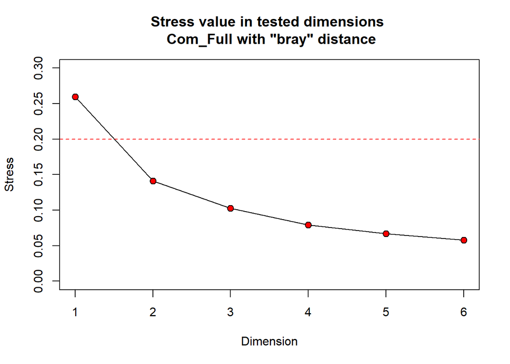

```
## [1] 0.25978326 0.14133431 0.10242021 0.07924772 0.06663897 0.05800465
```

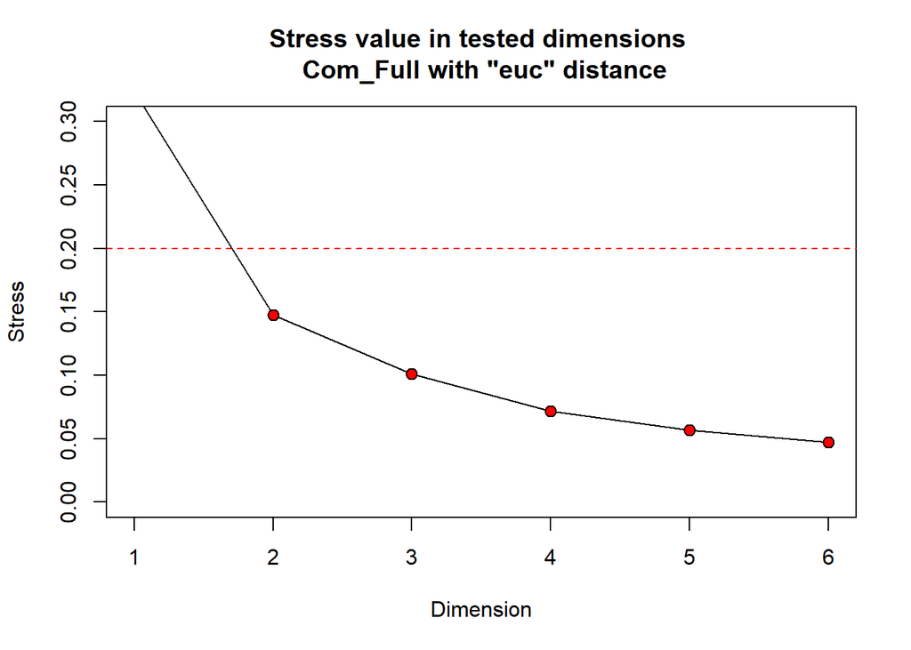

```
## [1] 0.32388190 0.14765193 0.10111307 0.07185451 0.05690653 0.04690577
```

```r
 dimcheckMDS_with_info(Com_Full,distance="euc",k=6,trymax=20,autotransform=F)
```

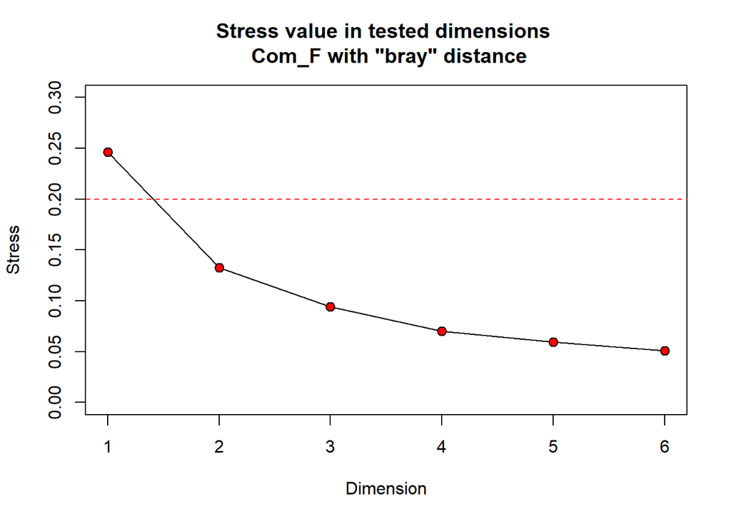

```
## [1] 0.24608751 0.13260107 0.09419956 0.06997676 0.05925992 0.05077650
```

```r
    # Flark

 dimcheckMDS_with_info(Com_F,distance="bray",k=6,trymax=20,autotransform=F)
```

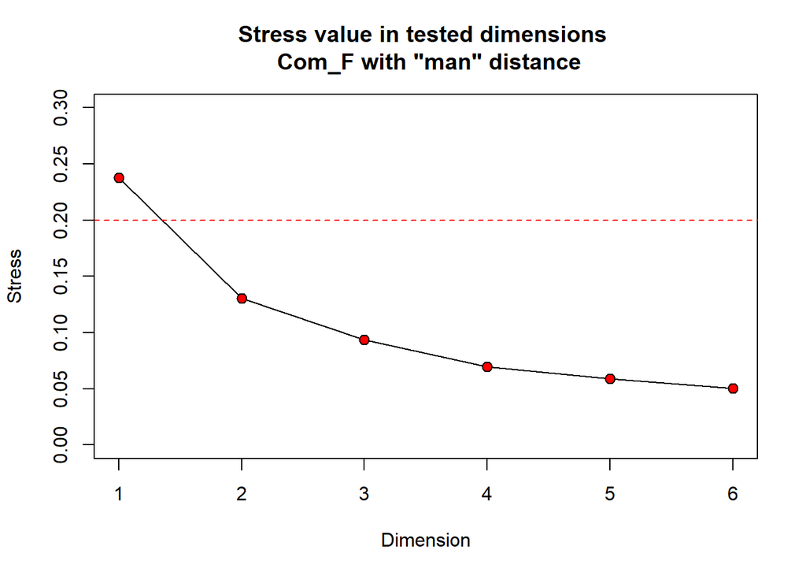

```
## [1] 0.23763755 0.13036209 0.09339139 0.06964033 0.05869685 0.05004536
```

```r
 dimcheckMDS_with_info(Com_F,distance="man",k=6,trymax=20,autotransform=F)
```

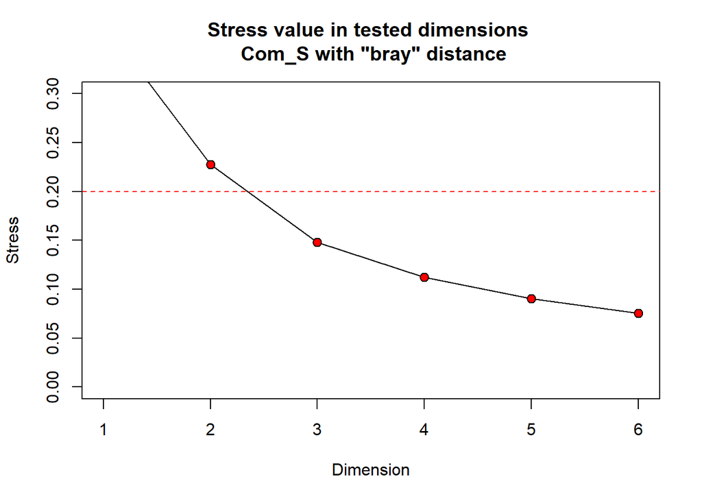

```
## [1] 0.37228262 0.22767442 0.14783306 0.11204168 0.09058333 0.07526212
```

```r
    # String

 dimcheckMDS_with_info(Com_S,distance="bray",k=6,trymax=20,autotransform=F)
```

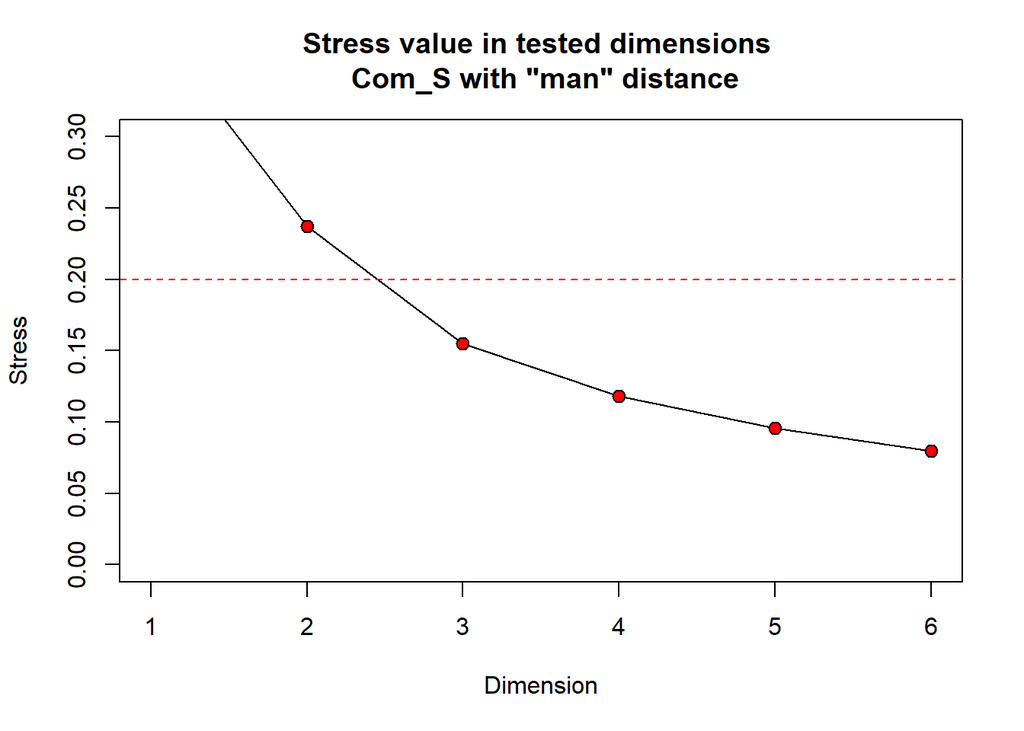

```
## [1] 0.37876833 0.23705224 0.15504979 0.11795198 0.09591802 0.07949441
```

```r
 dimcheckMDS_with_info(Com_S,distance="man",k=6,trymax=20,autotransform=F)
```

The plots show that for all indices and datasets the stress levels are quite similar at 2 dimensions. For Com_F and Com_Full both distance indices produce acceptable stress levels of lower than 0.15 with 2 dimensions. The stress values for the string dataset are comparably higher. The Bray-Curtis index performs noticeably better for this dataset with a stress value of 0.228 at 2 dimensions compared to 0.237 for the manhattan index.

# 6 Creating Ordinations

In this next code chunk we will create ordinations for the 3 datasets using the 2 different indices, using a random start or a pre defined start and with a local or global model. This results in 3x2x2x2 = 24 ordinations.

```r
set.seed(3)
# Building all MDS wih bray and man distance and use them as previous.best
# 2 dimensions, 25 tries and no transformation


# global model

 # Building NMDS for full dataset and a global model

    MDS_Com_Full_bray_g <- metaMDS(Com_Full, distance = "bray", k=2, try = 25, autotransform = FALSE,trace=FALSE, model = "global")

    MDS_Com_Full_alt_g <- metaMDS(Com_Full, distance = "euc", k=2, try = 25, autotransform = FALSE,trace=FALSE, model = "global")

    # with defined starting point (previous best)

    MDS_Com_Full_bray_pb_g<-metaMDS(Com_Full, previous.best=MDS_Com_Full_bray_g,trace=FALSE, autotransform = FALSE, k=2, try = 25,
                                    model = "global", distance = "bray")

    MDS_Com_Full_alt_pb_g<-metaMDS(Com_Full, previous.best=MDS_Com_Full_alt_g, trace= FALSE, autotransform = FALSE, k=2, try = 25,
                                   model = "global", distance ="euc")




  # Building NMDS for Flark dataset and a global model

    MDS_Com_F_bray_g <- metaMDS(Com_F, distance = "bray", k=2, try = 25, autotransform = FALSE,trace=FALSE, model = "global")

    MDS_Com_F_alt_g <- metaMDS(Com_F, distance = "man", k=2, try = 25, autotransform = FALSE,trace=FALSE, model = "global")

    # with defined starting point (previous best)


    MDS_Com_F_bray_pb_g<-metaMDS(Com_F, previous.best=MDS_Com_F_bray_g,trace=FALSE, autotransform = FALSE, k=2, try = 25,
                                 model = "global", distance = "bray")

    MDS_Com_F_alt_pb_g<-metaMDS(Com_F, previous.best=MDS_Com_F_alt_g,trace=FALSE, autotransform = FALSE, k=2, try = 25,
                                model = "global", distance ="man")



  # Building NMDS for Strings dataset and a global model

    MDS_Com_S_bray_g <- metaMDS(Com_S, distance = "bray", k=2, try = 25, autotransform = FALSE,trace=FALSE, model = "global")

    MDS_Com_S_alt_g <- metaMDS(Com_S, distance = "man", k=2, try = 25, autotransform = FALSE,trace=FALSE, model = "global")


      # with defined starting point (previous best)

    MDS_Com_S_bray_pb_g<-metaMDS(Com_S,previous.best=MDS_Com_S_bray_g, autotransform = FALSE, k=2, try = 25,
                                 trace=FALSE, model = "global", distance = "bray")

    MDS_Com_S_alt_pb_g<-metaMDS(Com_S,previous.best=MDS_Com_S_alt_g, autotransform = FALSE, k=2, try = 25,
                                trace=FALSE, model = "global", distance ="man")





# local model


 # Building NMDS for full dataset and a local model

    MDS_Com_Full_bray_l <- metaMDS(Com_Full, distance = "bray", k=2, try = 25, autotransform = FALSE,trace=FALSE, model = "local")

    MDS_Com_Full_alt_l <- metaMDS(Com_Full, distance = "euc", k=2, try = 25, autotransform = FALSE,trace=FALSE, model = "local")


    # with defined starting point (previous best)

    MDS_Com_Full_bray_pb_l<-metaMDS(Com_Full, previous.best=MDS_Com_Full_bray_l,trace=FALSE, autotransform = FALSE, k=2, try = 25,
                                       model = "local", distance = "bray")

    MDS_Com_Full_alt_pb_l<-metaMDS(Com_Full, previous.best=MDS_Com_Full_alt_l, trace= FALSE, autotransform = FALSE, k=2, try = 25,
                                   model = "local", distance ="euc" )



  # Building NMDS for Flark dataset and a local model

    MDS_Com_F_bray_l <- metaMDS(Com_F, distance = "bray", k=2, try = 25, autotransform = FALSE,trace=FALSE, model = "local")

    MDS_Com_F_alt_l <- metaMDS(Com_F, distance = "man", k=2, try = 25, autotransform = FALSE,trace=FALSE, model = "local")


    # with defined starting point (previous best)

    MDS_Com_F_bray_pb_l<-metaMDS(Com_F, previous.best=MDS_Com_F_bray_l,trace=FALSE, autotransform = FALSE, k=2, try = 25,
                                 model = "local", distance = "bray")

    MDS_Com_F_alt_pb_l<-metaMDS(Com_F, previous.best=MDS_Com_F_alt_l,trace=FALSE, autotransform = FALSE, k=2, try = 25,
                                model = "local", distance ="man")




  # Building NMDS for Strings dataset and a local model

    MDS_Com_S_bray_l <- metaMDS(Com_S, distance = "bray", k=2, try = 25, autotransform = FALSE,trace=FALSE, model = "local")

    MDS_Com_S_alt_l <- metaMDS(Com_S, distance = "man", k=2, try = 25, autotransform = FALSE,trace=FALSE, model = "local")


    # with defined starting point (previous best)

    MDS_Com_S_bray_pb_l<-metaMDS(Com_S,previous.best=MDS_Com_S_bray_l, autotransform = FALSE, k=2, try = 25,trace=FALSE,
                                 model = "local", distance = "bray")

    MDS_Com_S_alt_pb_l<-metaMDS(Com_S,previous.best=MDS_Com_S_alt_l, autotransform = FALSE, k=2, try = 25,trace=FALSE,
                                model = "local", distance ="man")
```

# 7 Comparing ordination metrics

## 7.1 Shepard diagrams (goodness of fit)

To assess the different variants, first we will plot shepard diagrams. The top row will be comparing the global and local model using the Bray-Curtis index, the bottom one will be the equivalent for the alternative index.

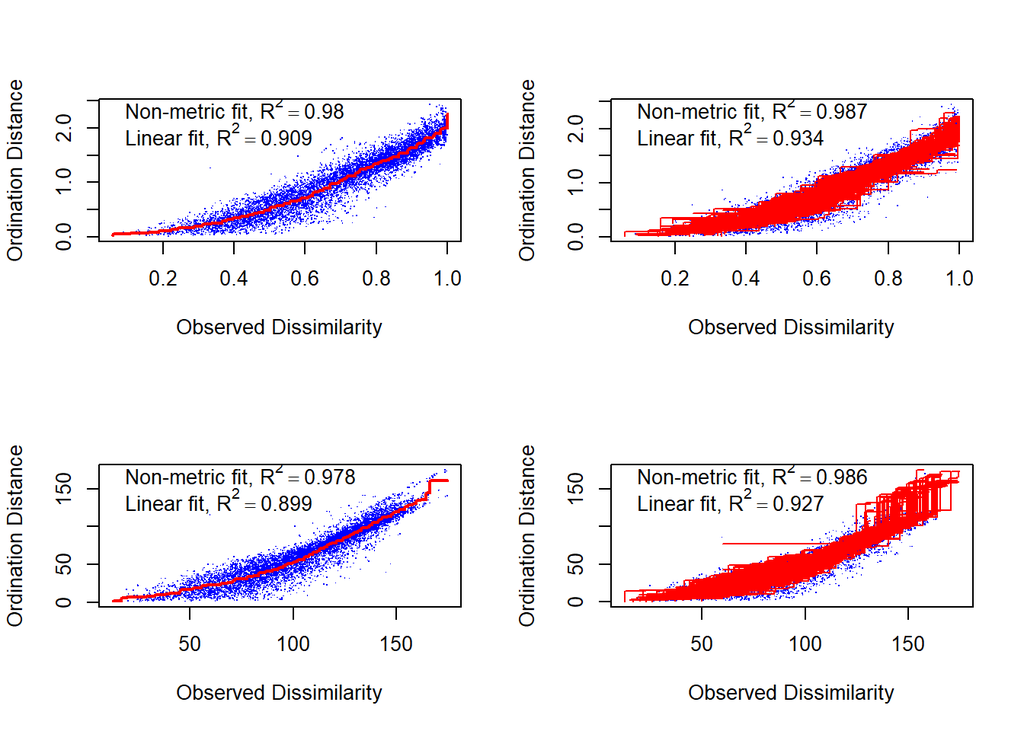

```r
par(mfrow=c(2,2)) # setting up plotting with 2 rows and 2 cols

# Stressplots for bray and alt index and local and global model


   # Full

  stressplot(MDS_Com_Full_bray_pb_g)
  stressplot(MDS_Com_Full_bray_pb_l)
  stressplot(MDS_Com_Full_alt_g)
  stressplot(MDS_Com_Full_alt_l)
```

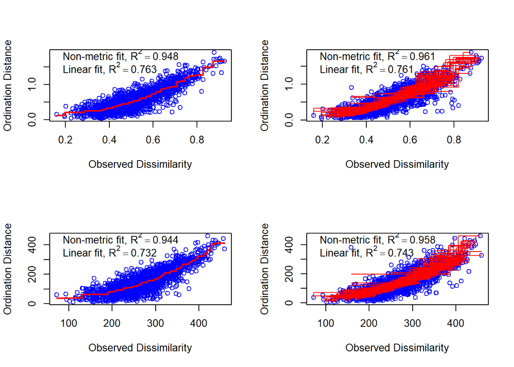

```r
   # Strings

  stressplot(MDS_Com_S_bray_g)
  stressplot(MDS_Com_S_bray_l)
  stressplot(MDS_Com_S_alt_g)
  stressplot(MDS_Com_S_alt_l)
```

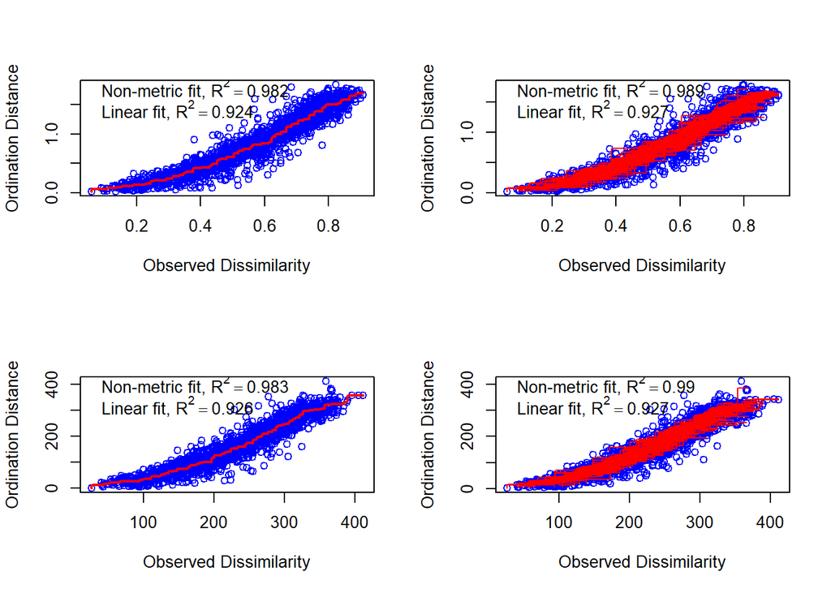

```r
  # Flarks

  stressplot(MDS_Com_F_bray_g)
  stressplot(MDS_Com_F_bray_l)
  stressplot(MDS_Com_F_alt_g)
  stressplot(MDS_Com_F_alt_l)
```

## 7.2 Stress

Creating a table containing all Stress values for the just created ordinations will help us compare them.

```r
# Create vectors to access the different ordinations

MDS_names <- c("MDS_Com_Full","MDS_Com_S","MDS_Com_F")
distances_g <- c("bray_g","alt_g","bray_pb_g","alt_pb_g")
distances_l <- c("bray_l","alt_l","bray_pb_l","alt_pb_l")


# Create empty data frames for stress data frames

stress_df_global <- data.frame(Full = c(1,1,1,2), String = 0, Flark = 1, row.names = c("bray_g","alt_g","bray_pb_g","alt_pb_g"))
stress_df_global_not_r <- data.frame(Full = c(1,1,1,2), String = 0, Flark = 1, row.names = c("bray_g","alt_g","bray_pb_g","alt_pb_g"))

stress_df_local <- data.frame(Full = c(1,1,1,2), String = 0, Flark = 1, row.names = c("bray_l","alt_l","bray_pb_l","alt_pb_l"))
stress_df_local_not_r <- data.frame(Full = c(1,1,1,2), String = 0, Flark = 1, row.names = c("bray_l","alt_l","bray_pb_l","alt_pb_l"))


# Create stress data frames

  # using loops over the name vectors to access the ordiantions

for (i in 1:length(MDS_names))
  {



  for (j in 1:length(distances_g))
    {

     stress_df_global[j,i] <- round(get(paste(MDS_names[i],distances_g[j] ,sep = "_"))[['stress']],2)

     # not rounded

    stress_df_global_not_r[j,i] <- get(paste(MDS_names[i],distances_g[j] ,sep = "_"))[['stress']]

  }



   for (k in 1:length(distances_l))
    {



      stress_df_local[k,i] <- round(get(paste(MDS_names[i],distances_l[k],sep = "_"))[['stress']],2)

      # not rounded

      stress_df_local_not_r[k,i] <- get(paste(MDS_names[i],distances_l[k],sep = "_"))[['stress']]

  }

}


kable(stress_df_global)
```

|  | Full | String | Flark |
| --- | --- | --- | --- |
| bray_g | 0.14 | 0.23 | 0.13 |
| alt_g | 0.15 | 0.24 | 0.13 |
| bray_pb_g | 0.14 | 0.23 | 0.13 |
| alt_pb_g | 0.15 | 0.24 | 0.13 |

```r
kable(stress_df_local)
```

|  | Full | String | Flark |
| --- | --- | --- | --- |
| bray_l | 0.11 | 0.2 | 0.1 |
| alt_l | 0.12 | 0.2 | 0.1 |
| bray_pb_l | 0.11 | 0.2 | 0.1 |
| alt_pb_l | 0.12 | 0.2 | 0.1 |

```r
# show a table of global - local models stress values

kable(stress_df_global -  stress_df_local)
```

|  | Full | String | Flark |
| --- | --- | --- | --- |
| bray_g | 0.03 | 0.03 | 0.03 |
| alt_g | 0.03 | 0.04 | 0.03 |
| bray_pb_g | 0.03 | 0.03 | 0.03 |
| alt_pb_g | 0.03 | 0.04 | 0.03 |

When comparing the alternative to the Bray-Curtis index, we can see that the alternative index performs the same or just slightly worse than the Bray-Curtis index. The last table above is subtracting the local from the global model matrix. We can see that the local models all perform better stresswise than the global models.

Also when looking at the global and local model stress values we can see that the results are generally the same as for the fit of the models.

```r
# create base of the stress data frame

stress_df_global_pre_best <- data.frame(Full = 1, String =1 , Flark = c(1,2), row.names = c("Bray_g","Alt_g"))
stress_df_local_pre_best <- data.frame(Full = 1, String =1 , Flark = c(1,2), row.names = c("Bray_l","Alt_l"))


# loop to subtract the previous best from the random start method stress values

for (i in c(1,2)) {

  for (j in c(1,2,3))
  {

  stress_df_local_pre_best[i,j] <- stress_df_local_not_r[i,j] - stress_df_local_not_r[i+2,j]
  stress_df_global_pre_best[i,j] <- stress_df_global_not_r[i,j] - stress_df_global_not_r[i+2,j]

  }
}

kable (stress_df_global_pre_best)
```

|  | Full | String | Flark |
| --- | --- | --- | --- |
| Bray_g | 0 | 0 | 0 |
| Alt_g | 0 | 0 | 0 |

```r
kable (stress_df_local_pre_best)
```

|  | Full | String | Flark |
| --- | --- | --- | --- |
| Bray_l | 0.0007144 | 0.0004969 | 0 |
| Alt_l | 0.0000000 | 0.0000000 | 0 |

In this table we substract the models using pervious defined starting points from the models using a random starting point. The models using previous.best all perform the same or slightly better. Therefore we will continue only using the previous.best ordinations.

# 8 Creating functions to plot the ordination

We will create several functions to be able to more easily built the plots and also for future use.

## 8.1 Functions to get chars from the right or left of a string

The following code implenets two functions to retrieve the n most left or right characters from a string. We will use these to plot specific text, retrieved from the dataset.

```r
substrRight <- function(x, n){
  # Trims down values in vector x to n char
  sapply(x, function(xx)
    substr(xx, (nchar(xx)-n+1), nchar(xx))
  )
}


substrleft <- function(x, n){
  # Trims down values in vector x to n char
  sapply(x, function(xx)
    substr(xx, (1), nchar(xx)-nchar(xx)+n)
  )
}
```

### 8.1.1 Function to create an ordination plot

Now we can implement function to further work with our built Ordinations. This function will use the function envfint to fit the environmental data onto our Ordination. Then it will build a ggplot. The parameters for this function are as followed:

- NMDS = Ordination
- Env = Environmental dataset
- Plot_group = Vector attributing the Spatial area to all of our 64/128 points
- colour_base = colours used to visualize the spatial areas (same length as number of spatial areas)
- shape_base = shapes used to visualize the spatial areas (same length as number of spatial areas)
- xlim and ylim = set up x axis and y axis
- add_s_F = boolean to signal if the plot should include specification of S for String and F for Flark for each point
- Env_output = “only” for only showing and creating the Env. output, True for showing and False for not showing the output
- limit_env = string vector specifying the Environmental variables to include (must be same as in colnames of Env)
- legend_position = “left”, “top”, “bottom” or “right”

```r
# Creating function to

Luis_gg_mds_env <- function(NMDS, Env, Plot_group, colour_base, shape_base, xlim = c(-1,1), ylim =c(-1,1),
                            add_S_F = FALSE, Env_output = FALSE, limit_env= "No", legend_position = "right") {



 # First fit NMDS with ENV data
  Env_model <-envfit(NMDS,Env,permu=999,na.rm=T)

# if env_output = "only just print the env model and then abort the function


 if (Env_output == "only")
 {
        print(Env_model)
 }
  # Plot using the plot group for colour, shape and fill
 else
 {
  # Access and calcuate variables necessary for plotting arrows
  Env_model_vec <- as.data.frame(Env_model$vectors$arrows*sqrt(Env_model$vectors$r))

  Env_model_vec$variables <- rownames(Env_model_vec)
    Env_model_vec$pvalues <- Env_model$vectors$pvals


# if we want to subset the environmental variables we can use the limit_env variable for that
    # check if limit_env was changed
  if(limit_env[1] != "No")
  {
    # subset the environmentel model data by the names given in limit env
    Env_model_vec <- Env_model_vec[limit_env,]
  }



  Env_model_vec_long <- data.frame(
    NMDS1 = Env_model_vec$NMDS1*1.2,
    NMDS2= Env_model_vec$NMDS2*1.2,
    variables= Env_model_vec$variables
    )


  # Rescale NMDS values
  NMDS_scores_df<- data.frame(
    MDS1 = rescale(NMDS$points[,1], to = c(-1,1)),
    MDS2 = rescale(NMDS$points[,2], to = c(-1,1))

                              )



 gg <- ggplot(data = NMDS_scores_df ,aes (x= MDS1 ,y = MDS2 ,
                                     color =as.factor(Plot_group),
                                     shape =as.factor(Plot_group),
                                     fill= as.factor(Plot_group),
                                     size = as.factor(Plot_group))
         )+



    # Add title to plot

      ggtitle(

        # depending on method used change title accordingly

        if(NMDS$call[9]!="Null()")  # if previous best was not used
        {

                 paste(" Ordination of", NMDS$data,"with", NMDS$call[9], "model and\n", NMDS$call[8], "used as previous best")

        }

        else                        # if previous best was used
       {
                 paste(" Ordination of", NMDS$data,"with", NMDS$call[8], "model and\n", NMDS$distance, "simillarity used")

        }


      )+



    # Add points

      geom_point()+



    # Setting the up the legend and values of the scales

      scale_color_manual(name = "Group", labels= c("SP 1","SP 2","SP 3","SP 4","SP 5"), values=colour_base)+
      scale_fill_manual(name = "Group", labels= c("SP 1","SP 2","SP 3","SP 4","SP 5"),values=colour_base)+
      scale_shape_manual(name = "Group", labels= c("SP 1","SP 2","SP 3","SP 4","SP 5"),values=shape_base)+
      scale_size_manual(name = "Group", labels= c("SP 1","SP 2","SP 3","SP 4","SP 5"),
                        values=c(3.5,3.5,3,3,3))+



    # Legend design

      theme(legend.position = legend_position,  # Legend position
            legend.title  = element_text(color = "blue", size = 14, hjust = 0.5),  # legend title
            legend.background = element_rect(size=0.5, colour ="black"))+ # legend border



      # Plot background

      theme(panel.background = element_rect(fill= "white", colour= "black"))+




      # setting up the axis

      coord_cartesian( xlim =xlim, ylim =ylim)+



       # clearing the axis

      theme(axis.line=element_blank(),
            axis.text.x=element_blank(),
            axis.text.y=element_blank(),
            axis.ticks=element_blank(),
            axis.title.x=element_blank(),
            axis.title.y=element_blank())+



     # adding the env factor arrows

      geom_segment(data = Env_model_vec_long,
                   aes(x = 0, xend = NMDS1, y = 0, yend = NMDS2),
                   arrow = arrow(length = unit(0.25, "cm")),
                   colour="black",
                   inherit.aes = FALSE)+



      # adding the text to the arrows

         geom_text(data = Env_model_vec_long,
                   # position text depending on the direction of the arrow
                  aes(x = NMDS1+(if (NMDS1[1]>=0){0.05}else {-0.05}),
                      y=NMDS2,
                      label = variables),
                  size = 4,
                  inherit.aes = FALSE,
                  )+



      # add Stress text on the top right

         annotate( # if clauses for the case of inverted axis
                "text", x=xlim[2]+if (xlim[1]>=0) {0.15} else {-0.15},
                 y=-if (ylim[2]<ylim[1]){-ylim[2]}  else ylim[1],
                 label= paste("2D Stress:",round(NMDS$stress,2)),
                 size = 3.5,
                fontface = "bold"
                )+



      # if add_S_F was set to TRUE add S / F to all points

          if (add_S_F) {
        geom_text(data= NMDS_scores_df,
                  aes(
                      x= MDS1,
                      y= MDS2-0.05,
                    # get one char from the right of the row names of the original data used
                      label =substrRight(row.names(get(paste(NMDS$data,sep = ""))),1)
                      ),
                  inherit.aes = FALSE,
                  size = 2.8
                )
      }



 # print the environmental model if the condition was set when calling the function

  if (Env_output == TRUE)
  {
    print(Env_model)
  }


 # print the plot
 gg
  }

}
```

# 9 Comparing ordination plots and environmental models

## 9.1 Setting up base vectors for plotting

We will use vectors specifying which color and shape we want to use to depict the different spatial area groups in the ordination plot.

```r
Pch_base <- c(3,4,23,24,25) # pch base to use for Sp 1-5
Col_base <- c("darkorange1","darkorange1","blue","blue","blue")  # colour base to use for Sp 1-5
```

## 9.2 Compare local and global model ordinations

### 9.2.1 Create ordinations

Lets first create and save the function for all datasets and the ordinations using a pre defined starting point and the bray distance matrix.

```r
# Plotting the different "previous.best" configurations with bray distance


  # Full dataset

    # local

 gg_Full_bray_pb_l <- Luis_gg_mds_env(NMDS= MDS_Com_Full_bray_pb_l, Env = Env_Full, Plot_group= Sp_vec_full,
                  colour_base = Col_base, shape_base= Pch_base,add_S_F = TRUE,
                  xlim = c(1,-1), ylim = c(1,-1),legend_position = "bottom", limit_env = c("Ca","EC"))
     # global

 gg_Full_bray_pb_g <- Luis_gg_mds_env(NMDS= MDS_Com_Full_bray_pb_g, Env = Env_Full, Plot_group= Sp_vec_full,
                  colour_base = Col_base, shape_base= Pch_base, add_S_F = TRUE,
                  xlim = c(1,-1), ylim = c(1,-1),legend_position = "bottom", limit_env = c("Ca","EC"))



  # Flarks

      # local

gg_F_bray_pb_l <-  Luis_gg_mds_env(NMDS= MDS_Com_F_bray_pb_l, Env = Env, Plot_group= Sp_vec,
                  colour_base = Col_base, shape_base= Pch_base, xlim = c(-1,1), ylim = c(1,-1),legend_position = "bottom")

      # global

gg_F_bray_pb_g <-  Luis_gg_mds_env(NMDS= MDS_Com_F_bray_pb_g, Env = Env, Plot_group= Sp_vec,
                  colour_base = Col_base, shape_base= Pch_base, xlim = c(-1,1), ylim = c(1,-1),legend_position = "bottom")



  # Strings

      # local

gg_S_bray_pb_l <-  Luis_gg_mds_env(NMDS= MDS_Com_S_bray_pb_l, Env = Env, Plot_group= Sp_vec,
                  colour_base = Col_base, shape_base= Pch_base, xlim = c(-1,1), ylim = c(-1,1),legend_position = "bottom")

       # global

gg_S_bray_pb_g <-  Luis_gg_mds_env(NMDS= MDS_Com_S_bray_pb_g, Env = Env, Plot_group= Sp_vec,
                  colour_base = Col_base, shape_base= Pch_base, xlim = c(-1,1), ylim = c(-1,1),legend_position = "bottom")
```

### 9.2.2 Ordination plots

We will compare the global and local model of these ordinations side by side.

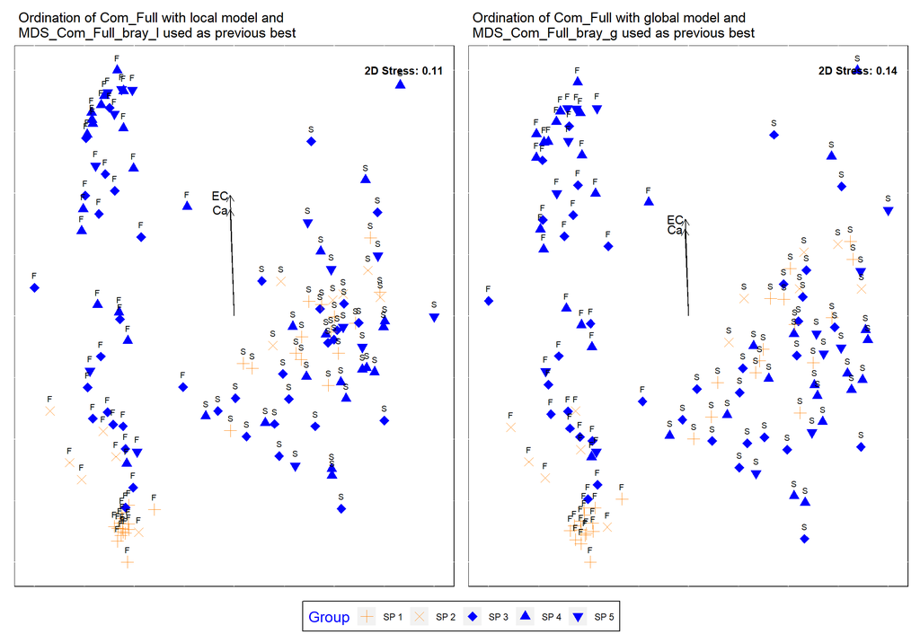

```r
# use patchwork package to arrange the ggplots side by side and use plot_layout and theme to use a single legend which is on the bottom

gg_Full_bray_pb_l + gg_Full_bray_pb_g + plot_layout(guides = "collect") & theme(legend.position = "bottom")
```

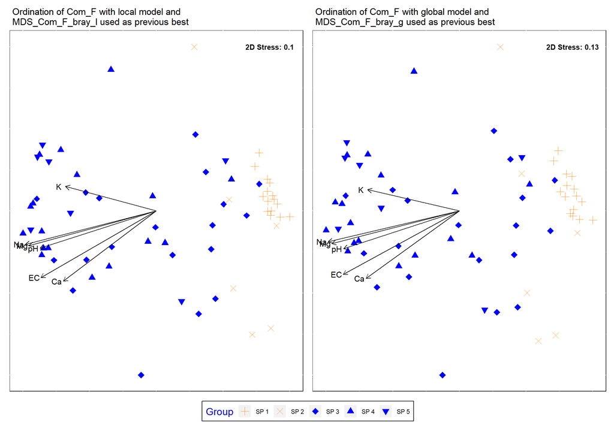

```r
gg_F_bray_pb_l + gg_F_bray_pb_g + plot_layout(guides = "collect") & theme(legend.position = "bottom")
```

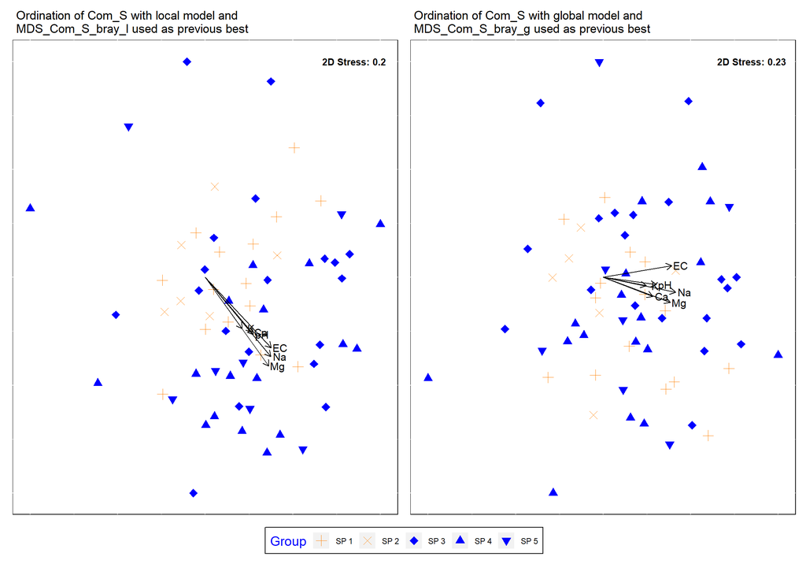

```r
gg_S_bray_pb_l + gg_S_bray_pb_g + plot_layout(guides = "collect") & theme(legend.position = "bottom")
```

Again we can see in the top right corners that the stress levels using the local models are smaller.

#### 9.2.2.1 Full dataset:

Authors observation:

Flarks (left side of ordination Fig. 6a) ordinate vertically along water chemistry vectors (EC, Ca2+), while strings (right side of ordination) form a widely scattered group distributed along both x and y axes. Flarks from Spatial Areas 1 and 2 form a tight cluster toward the lower left, while Spatial Areas 3–5 flarks form more scattered groups to upper left (Fig. 6a).

Using local model:

The main observable difference is that using the local model the main Sp 1-2 flark cluster is more tightly packed. The main observations do not change.

#### 9.2.2.2 Flark dataset:

Authors interpretation:

Flark plots are distributed widely on the ordination of ‘flarks only’ (Fig. 6c), with plots from Spatial Areas 1–2 placed to the right on the ordination and those from Spatial Areas 3–5 to the center and left. Spatial Area 1 is particularly distinctive.

Using local model:

No noteworthy difference.

#### 9.2.2.3 String dataset:

Authors interpretation:

String plots occur intermixed in the ordination of ‘Strings only’ (Fig. 6b), with considerable variation within each spatial area; however, Spatial Areas 1–2 string plots are, in general, located to the left of the ordination, while those from spatial Areas 3–5 are located to the upper right.

Using local model:

For the string dataset we can see that with the local model we receive an ordination seemingly easier to interpret. The spatial area 1 and 2 points seem to be more clearly seperated from the majority of points belonging to groups 3 to 5. Also the general differentiation between points of areas 1 and 2 seems to be orthogonal to the environmental factors. This seems to better represent the findings of Vitt et al. regarding the distribution of the level of water parameters: “Spatial Areas 1–2 were lower in all surface water parameters compared to those from Spatial Areas 3–5”. Looking at the findings by Vitt et al. in Fig. 5, we can see that SP 1 and have a lower range in cation levels compared to Sp 3 to 5. This is also more clearly represented using the local model.

## 9.3 Comparing Alternative index to Bray-Curtis index

We can now also compare the local models used above with the corresponding models using the alternative distance indices.

### 9.3.1 Correlation to environmental data

We already assessed the general correlation using different dissimilarity indices. Now we can take a closer look and compare the results of the environmental fit using the Bray-Curtis or the alternative index.

```r
# Creating alternative, previous best ordinations with a local model and only showing the env model output

# Plotting the different "previous.best" configurations


  # Full dataset


     # man previous best

 gg_Full_alt_pb_l <- Luis_gg_mds_env(NMDS= MDS_Com_Full_alt_pb_l, Env = Env_Full, Plot_group= Sp_vec_full,
                  colour_base = Col_base, shape_base= Pch_base, add_S_F = TRUE,
                  xlim = c(1,-1), ylim = c(1,-1), limit_env = c("Ca","EC"), Env_output = TRUE)
```

```
##
## ***VECTORS
##
##       NMDS1    NMDS2     r2 Pr(>r)
## Ca  0.17733 -0.98415 0.1080  0.001 ***
## K   0.17348 -0.98484 0.0910  0.006 **
## Mg  0.17555 -0.98447 0.1657  0.001 ***
## Na  0.19074 -0.98164 0.1727  0.001 ***
## pH  0.17643 -0.98431 0.1527  0.001 ***
## EC  0.17399 -0.98475 0.1419  0.001 ***
## ---
## Signif. codes:  0 '***' 0.001 '**' 0.01 '*' 0.05 '.' 0.1 ' ' 1
## Permutation: free
## Number of permutations: 999
```

```r
    # bray env only

Luis_gg_mds_env(NMDS= MDS_Com_Full_bray_pb_l, Env = Env_Full, Env_output = "only")
```

```
##
## ***VECTORS
##
##        NMDS1     NMDS2     r2 Pr(>r)
## Ca  0.050044 -0.998750 0.1309  0.002 **
## K  -0.038444 -0.999260 0.0891  0.004 **
## Mg  0.031046 -0.999520 0.1981  0.001 ***
## Na  0.039179 -0.999230 0.1970  0.001 ***
## pH  0.047958 -0.998850 0.1698  0.001 ***
## EC  0.043291 -0.999060 0.1681  0.001 ***
## ---
## Signif. codes:  0 '***' 0.001 '**' 0.01 '*' 0.05 '.' 0.1 ' ' 1
## Permutation: free
## Number of permutations: 999
```

```r
  # Strings

       # man previous best

 gg_S_alt_pb_l <-  Luis_gg_mds_env(NMDS= MDS_Com_S_alt_pb_l, Env = Env, Plot_group= Sp_vec,
                  colour_base = Col_base, shape_base= Pch_base, xlim = c(-1,1), ylim = c(-1,1), Env_output = TRUE)
```

```
##
## ***VECTORS
##
##       NMDS1    NMDS2     r2 Pr(>r)
## Ca  0.96668 -0.25599 0.1117  0.026 *
## K   0.71571 -0.69839 0.1120  0.033 *
## Mg  0.85528 -0.51816 0.2307  0.001 ***
## Na  0.86474 -0.50222 0.2264  0.002 **
## pH  0.86501 -0.50175 0.1282  0.016 *
## EC  0.86397 -0.50355 0.2456  0.001 ***
## ---
## Signif. codes:  0 '***' 0.001 '**' 0.01 '*' 0.05 '.' 0.1 ' ' 1
## Permutation: free
## Number of permutations: 999
```

```r
        # bray previous best

  Luis_gg_mds_env(NMDS= MDS_Com_S_bray_pb_l, Env = Env, Env_output = "only")
```

```
##
## ***VECTORS
##
##       NMDS1    NMDS2     r2 Pr(>r)
## Ca  0.72255 -0.69132 0.0946  0.051 .
## K   0.66572 -0.74620 0.0703  0.105
## Mg  0.66286 -0.74874 0.2091  0.002 **
## Na  0.71345 -0.70070 0.1907  0.002 **
## pH  0.71927 -0.69473 0.1012  0.040 *
## EC  0.75645 -0.65405 0.1729  0.002 **
## ---
## Signif. codes:  0 '***' 0.001 '**' 0.01 '*' 0.05 '.' 0.1 ' ' 1
## Permutation: free
## Number of permutations: 999
```

```r
  # Flarks


      # man previous best

   gg_F_alt_pb_l <-  Luis_gg_mds_env(NMDS= MDS_Com_F_alt_pb_l, Env = Env, Plot_group= Sp_vec,
                  colour_base = Col_base, shape_base= Pch_base, xlim = c(-1,1), ylim = c(1,-1), Env_output = TRUE)
```

```
##
## ***VECTORS
##
##       NMDS1    NMDS2     r2 Pr(>r)
## Ca -0.88688  0.46201 0.4486  0.001 ***
## K  -0.98079 -0.19509 0.3563  0.001 ***
## Mg -0.98531  0.17079 0.6625  0.001 ***
## Na -0.98820  0.15318 0.6931  0.001 ***
## pH -0.97826  0.20738 0.5742  0.001 ***
## EC -0.93469  0.35546 0.6311  0.001 ***
## ---
## Signif. codes:  0 '***' 0.001 '**' 0.01 '*' 0.05 '.' 0.1 ' ' 1
## Permutation: free
## Number of permutations: 999
```

```r
     # bray previous best

  Luis_gg_mds_env(NMDS= MDS_Com_F_bray_pb_l, Env = Env, Env_output = "only")
```

```
##
## ***VECTORS
##
##       NMDS1    NMDS2     r2 Pr(>r)
## Ca -0.85252  0.52269 0.4649  0.001 ***
## K  -0.97674 -0.21443 0.3384  0.001 ***
## Mg -0.97646  0.21571 0.6652  0.001 ***
## Na -0.97920  0.20292 0.6978  0.001 ***
## pH -0.96784  0.25157 0.5649  0.001 ***
## EC -0.90545  0.42446 0.6359  0.001 ***
## ---
## Signif. codes:  0 '***' 0.001 '**' 0.01 '*' 0.05 '.' 0.1 ' ' 1
## Permutation: free
## Number of permutations: 999
```

### 9.3.2 plots

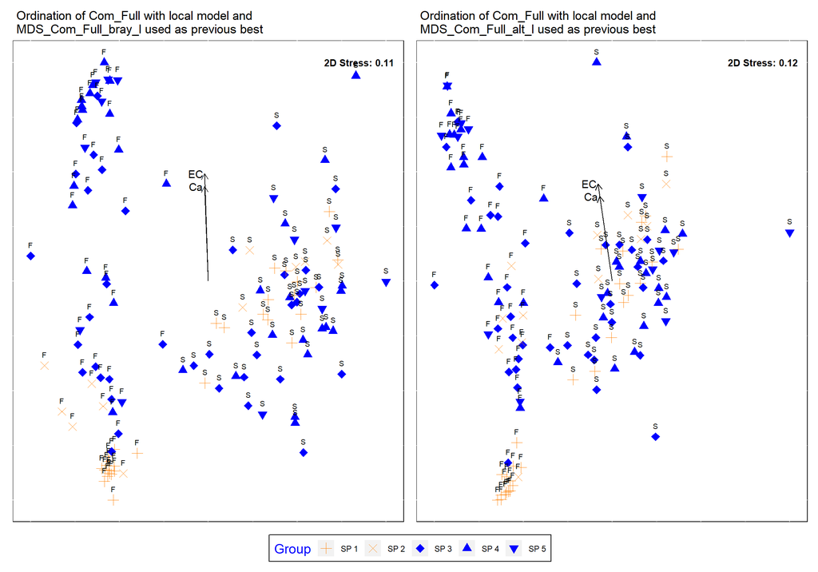

```r
# Plotting the different "previous.best" configurations


# Use patchwork package to arrange the ggplots side by side and use plot_layout and theme to use a single legend which is on the bottom

   gg_Full_bray_pb_l + gg_Full_alt_pb_l + plot_layout(guides = "collect") & theme(legend.position = "bottom")
```

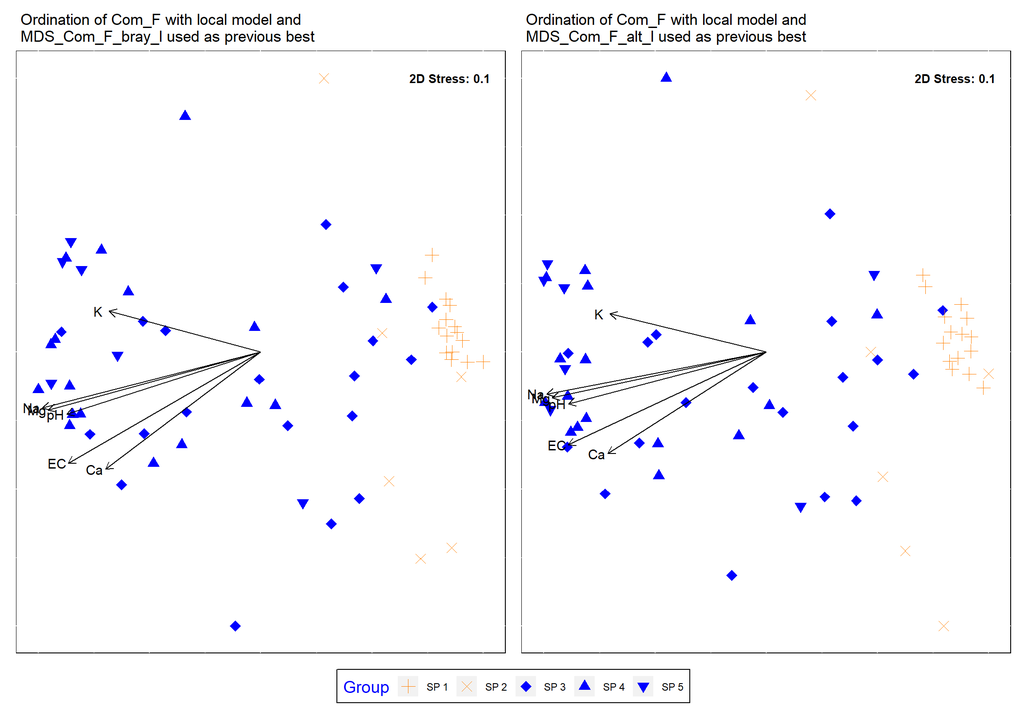

```r
   gg_F_bray_pb_l +gg_F_alt_pb_l + plot_layout(guides = "collect") & theme(legend.position = "bottom")
```

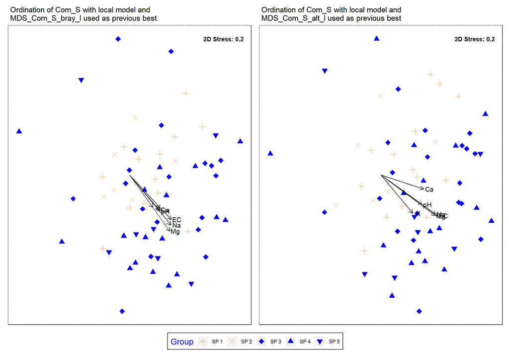

```r
   gg_S_bray_pb_l + gg_S_alt_pb_l + plot_layout(guides = "collect") & theme(legend.position = "bottom")
```

While there is only a small difference for the separate string and flark dataset, for the full dataset we can see a more clear picture using the Bray-Curtis index. The separation between strings and flarks is more pronounced. Also the separation between SP 1-2 and SP 3-5 seems to more clearly represented using the Bray-Curtis index, which aligns with the setup hypothesis.

# 10 Species abundances on the Full dataset

After assessing the different options for the ordinations. The next part focuses only on replicating the produced plots from Vitt et al. focusing on specific species and plotting them onto the ordination of the full dataset. The ordination using a global model and a a pre defined starting point seems to most closely match the ones by Vitt et al.

## 10.1 Creating a function

```r
# creating a function called Luis_gg_mds_species
Luis_gg_mds_species <- function (NMDS, Plot_group, species_name_underscore, colour_base, xlim = c(1.25,-1.25), ylim= c(0.85,-1.05))

{




  # Setting up a data frame with our NMDS points data and adding the Plot group number
  # and the Species abundance data for our wanted species

    # binding data frame of the NMDS points and the plot group
  Spe_MDS<- cbind(data.frame(NMDS$points),Plot_group)
    # accessing the original data used for the NMDS and   the column of the wanted species
  Spe_MDS$species <- get(paste(NMDS$data))[[(paste(species_name_underscore))]]


  # Creating the Plot

    # for the base ggplot, we use the Plot group for our fill (colour) and the species abundance for the size scaling

  gg <- ggplot(data = Spe_MDS, aes(x = MDS1 ,y = MDS2,fill= as.factor(Plot_group),size=species))+


    # adding points with X = NMDS1 and y= NMDS2

        geom_point(

          color = "black", pch=21

          )+



    # fill legend, scaling and legend title (name)

        scale_fill_manual(

          name = "Group",

          labels = c("Sp 1", "Sp 2", "Sp 3", "Sp 4",  "Sp 5"),

          values = Col_base,

          guide = guide_legend(override.aes = list(size= 3))

        )+



    # size legend, scaling and legend title (name)

        scale_size(

          labels  = c(
            round(max(Spe_MDS$species)/10,0),

            round(
              (
                (max(Spe_MDS$species) - round(max(Spe_MDS$species)/10,0))
                /3+  round(max(Spe_MDS$species))/10)
              ,0),

            round(
              2* (max(Spe_MDS$species) - round(max(Spe_MDS$species)/10,0))/3  +  round(max(Spe_MDS$species))/10
              ,0),
            max(Spe_MDS$species)
            ),  # legend labeling


          range = c(0,35), # size range


          breaks  = c(
            round(max(Spe_MDS$species)/10,0),

            round(
              (
                (max(Spe_MDS$species) - round(max(Spe_MDS$species)/10,0))
                /3+  round(max(Spe_MDS$species))/10)
              ,0),

            round(
              2* (max(Spe_MDS$species) - round(max(Spe_MDS$species)/10,0))/3  +  round(max(Spe_MDS$species))/10
              ,0),
            max(Spe_MDS$species)
            ), # legend breakpoints

          name = paste(   # naming the size legend and pasting the first three letters of the two species name words

            substrleft(                    #getting the left characters from a string
              # splitting the species name by "_" and taking 3 letters of the first word
              str_split(species_name_underscore, "_", simplify = TRUE)[,1],3
            ),

            " ", # pasting space

            substrleft(
              # splitting the species name by "_" and taking 3 letters of the first word
              str_split(species_name_underscore, "_", simplify = TRUE)[,2],3)
          )

            )+



    # legend design

        guides(

          fill = guide_legend( # fill legend

            override.aes = list(size = 5),  # change the size of the legend elements

            title.theme = element_text(colour = "blue")), # change the colour of the legend title

        # size legend: change the fill of the elements
          size = guide_legend(override.aes = list(fill = "gray") ,
                              title.theme = element_text(colour = "blue"))

        )    +



     # add S or F for Strings and Flarks

        geom_text(

          # get one letter from the right of the rownames of the original data
          label=substrRight(row.names(get(paste(NMDS$data))),1),

          check_overlap = T, size =3.5 # change the size of the letters

        ) +



    # plot background

        theme(

          panel.background = element_rect(fill= "white", colour= "black")

           )+



    # clear the plot from axis

        theme(

              axis.line=element_blank(),
              axis.text.x=element_blank(),
              axis.text.y=element_blank(),
              axis.ticks=element_blank(),
              axis.title.x=element_blank(),
              axis.title.y=element_blank())+


    #
        theme(

              legend.key=element_rect(fill="white",),  # get rid of gray legend background

              legend.background = element_rect(size=0.5, colour ="black"), # create border around legends

              legend.position="right",      # set the legend position to right

              plot.title = element_text(hjust = 0.5),        # set the plot title to the left

        ) +



    # Add the stress as text to the plot

        annotate(
          "text", # type of annotation
          x=xlim[2]+0.1,
          y=ylim[2]-0.05,
          label= paste("2D Stress:",round(NMDS$stress,2)),  # text to paste, and rounding the stress level with 2 digits
          size = 3.5, # size of the text
          fontface = "bold"
        )+



    # Add the species Name on the bottom right

        annotate(

          "text",
          label = paste( gsub(x= species_name_underscore,"_"," ")),
          size = 8,
          x =xlim[2]+ 0.5,
          y=ylim[1]+0.03

        )+



    # Settin up the axis

        coord_cartesian(

          xlim =xlim, ylim =ylim

          )+



    # Add title to plot

         ggtitle(

        # depending on method used change title accordingly

        if(NMDS$call[9]!="Null()")  # if previous best was not used
        {

                 paste(" Ordination of", NMDS$data,"with", NMDS$call[9], "model and\n", NMDS$call[8], "used as previous best")

        }

        else                        # if previous best was used
       {
                 paste(" Ordination of", NMDS$data,"with", NMDS$call[8], "model and\n", NMDS$distance, "simillarity used")

        }


      )






  # Output the ggplot

  print(gg)
}
```

## 10.2 Plotting different species

### 10.2.1 Tomentypnum nitens

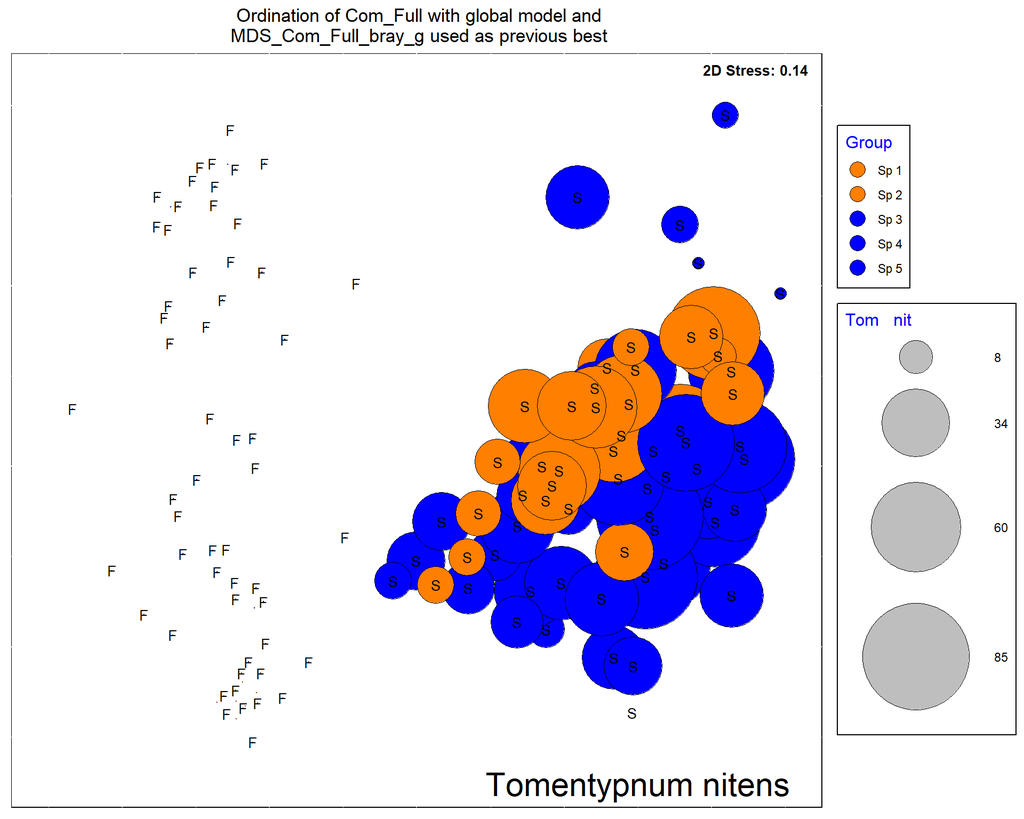

```r
Luis_gg_mds_species(MDS_Com_Full_bray_pb_g, Plot_group = Sp_vec_full, species_name_underscore = "Tomentypnum_nitens", colour_base = Col_base)
```

Corresponding Text:

Tomentypnum nitens (Fig. 6d) – variably abundant on all strings, but absent from all flarks.

Peat from drier habitats (strings) have remains of Tomentypnum nitens along with small quantities of wood, bark, and needles from Larix and Betula (Vitt and House, 2021)

### 10.2.2 Scorpidium Scorpiodes

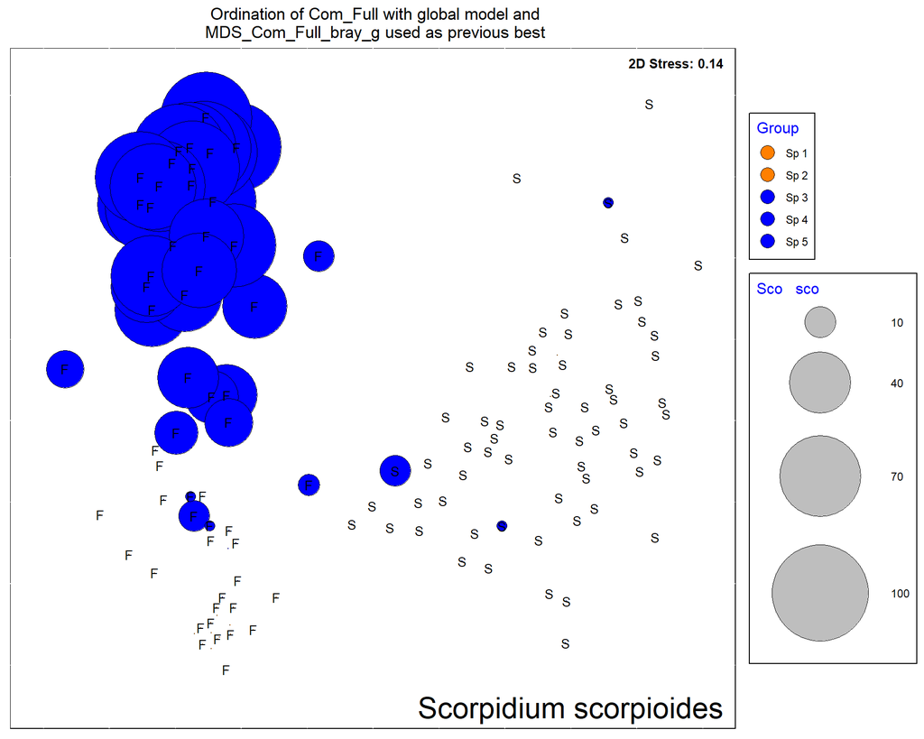

```r
Luis_gg_mds_species(NMDS= MDS_Com_Full_bray_pb_g, Plot_group = Sp_vec_full, species_name_underscore = "Scorpidium_scorpioides", colour_base = Col_base)
```

Corresponding Text:

Scorpidium scorpioides (Fig. 6e) – very abundant in flarks of Spatial Areas 3–5, nearly absent from Spatial Area 1 flarks; only occasionally present on strings. Abundance of this species is significantly higher in Spatial Areas 3–5 compared to spatial Areas 1–2 (H = 35.61, p < 0.001).

Across Spatial Areas 3 through 5, a number of species are restricted to areas of high cation concentrations and high pH. These species include not only the dominant species (e.g., Scorpidium scorpioides), but also more infrequent ones.

Peat in wet habitats (flarks) is largely composed of the bryophytes Hamatocaulis vernicosus and Scorpidium scorpioides, along with sedge roots and leaves.

### 10.2.3 Hamatocaulis vernicosus

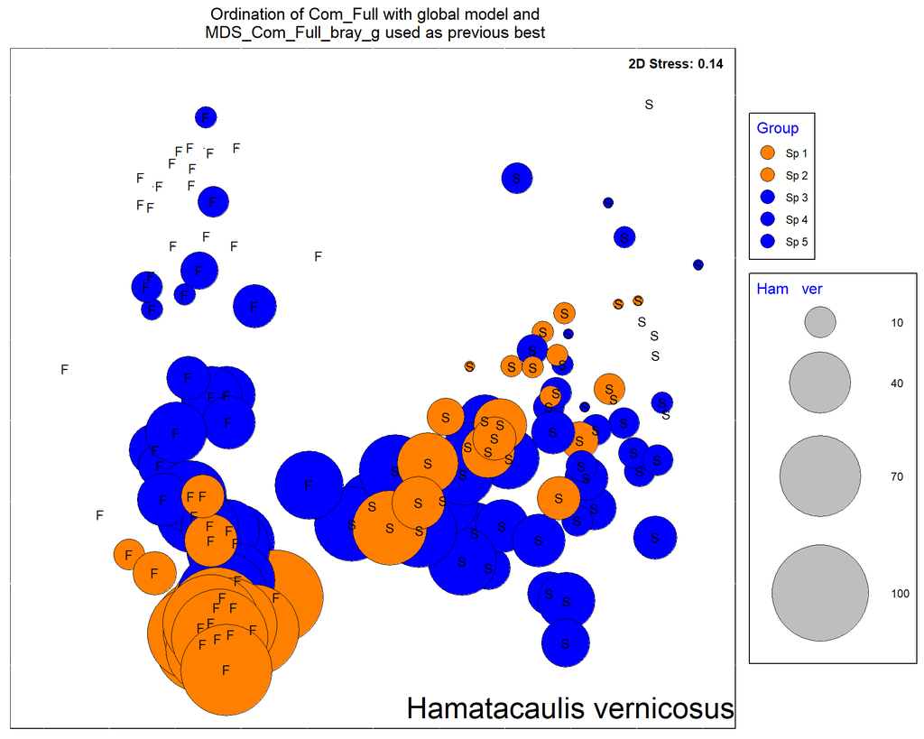

```r
Luis_gg_mds_species(MDS_Com_Full_bray_pb_g, Plot_group = Sp_vec_full, species_name_underscore = "Hamatacaulis_vernicosus", colour_base = Col_base)
```

Corresponding Text:

Hamatocaulis vernicosus (Fig. 6f) – the dominant species in Spatial Areas 1–2 flarks and less abundant on Spatial Area 3–5 strings, absent or rare and infrequent in flarks of Spatial Areas 3–5. The abundance of this species is significantly greater in Spatial Area 1 (H = 38.27, p < 0.001)”

Flarks with less abundant cations and lower pH also have a set of characteristic species (e.g., Hamatocaulis vernicosus, Carex diandra). Although these species may occur in lower abundance on strings in areas with high cations and pH (see Fig. 6h–i), they achieve high abundance only in Spatial Area 1 where cations have lower concentrations. These species and associated water chemistry would be characteristic of moderate-rich fens.

Peat in wet habitats (flarks) is largely composed of the bryophytes Hamatocaulis vernicosus and Scorpidium scorpioides, along with sedge roots and leaves.

# 11 Exploring Bryophyte only data

Finally we want to explore the bryophytes and vascular plants community data separately. First we will look at the flarks.

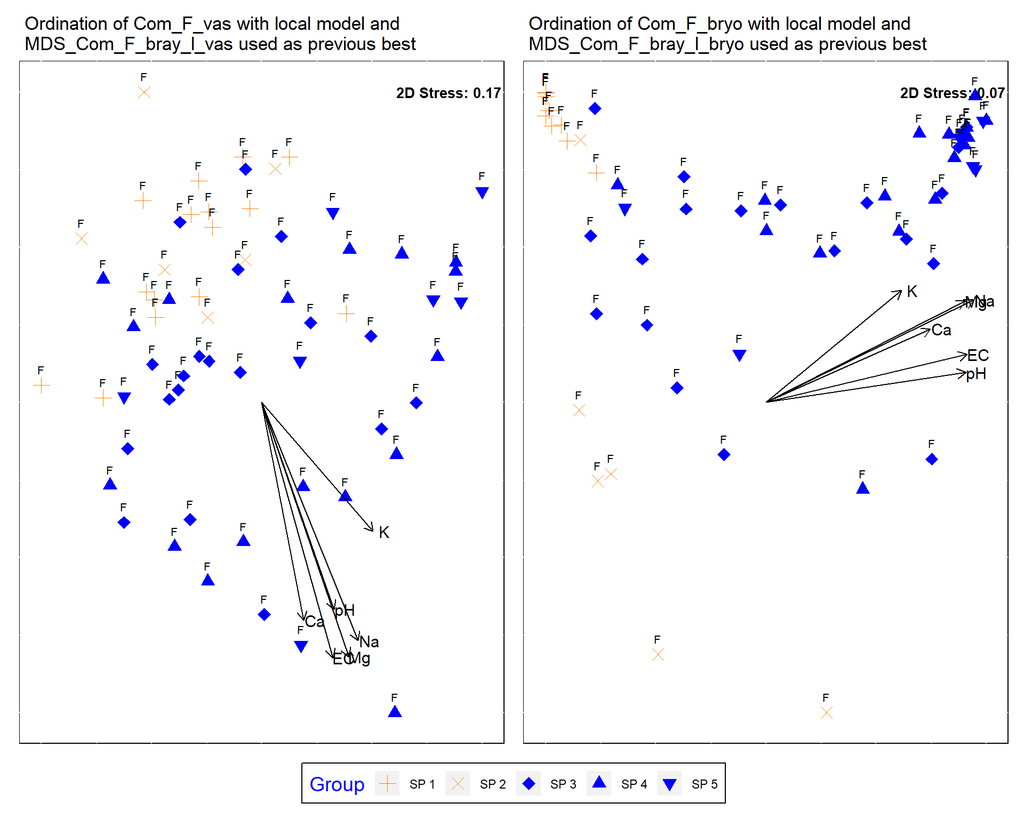

```r
set.seed(1431)

Com_F_bryo <- Com_F[50:90] # Flark data set only containing bryophytes
Com_F_vas <- Com_F[1:49] # Flark data set only containing vascular plants


# Ordinations for Flark


  # bryophytes

     MDS_Com_F_bray_l_bryo <- metaMDS(Com_F_bryo, distance = "bray", k=2, try = 25, autotransform = FALSE,trace=FALSE, model = "local")

    MDS_Com_F_bray_pb_l_bryo<-metaMDS(Com_F_bryo, previous.best=MDS_Com_F_bray_l_bryo,trace=FALSE, autotransform = FALSE, k=2, try = 25,
                                       model = "local", distance = "bray")



      # Creating Plot

         gg_F_bray_pb_l_bry <- Luis_gg_mds_env(NMDS= MDS_Com_F_bray_pb_l_bryo, Env = Env, Plot_group= Sp_vec,
                  colour_base = Col_base, shape_base= Pch_base,add_S_F = TRUE,
                           xlim = c(1,-1), ylim = c(1,-1),legend_position = "bottom")



   # vascular plants



         MDS_Com_F_bray_l_vas <- metaMDS(Com_F_vas, distance = "bray", k=2, try = 25, autotransform = FALSE,trace=FALSE, model = "local")

         MDS_Com_F_bray_pb_l_vas<-metaMDS(Com_F_vas, previous.best=MDS_Com_F_bray_l_vas,trace=FALSE, autotransform = FALSE, k=2, try = 25,
                                       model = "local", distance = "bray")



      # Creating Plot

         gg_F_bray_pb_l_vas <- Luis_gg_mds_env(NMDS= MDS_Com_F_bray_pb_l_vas, Env = Env, Plot_group= Sp_vec,
                  colour_base = Col_base, shape_base= Pch_base,add_S_F = TRUE,
                           xlim = c(1,-1), ylim = c(1,-1),legend_position = "bottom")





# Ploting

gg_F_bray_pb_l_vas + gg_F_bray_pb_l_bry + plot_layout(guides = "collect") & theme(legend.position = "bottom")
```

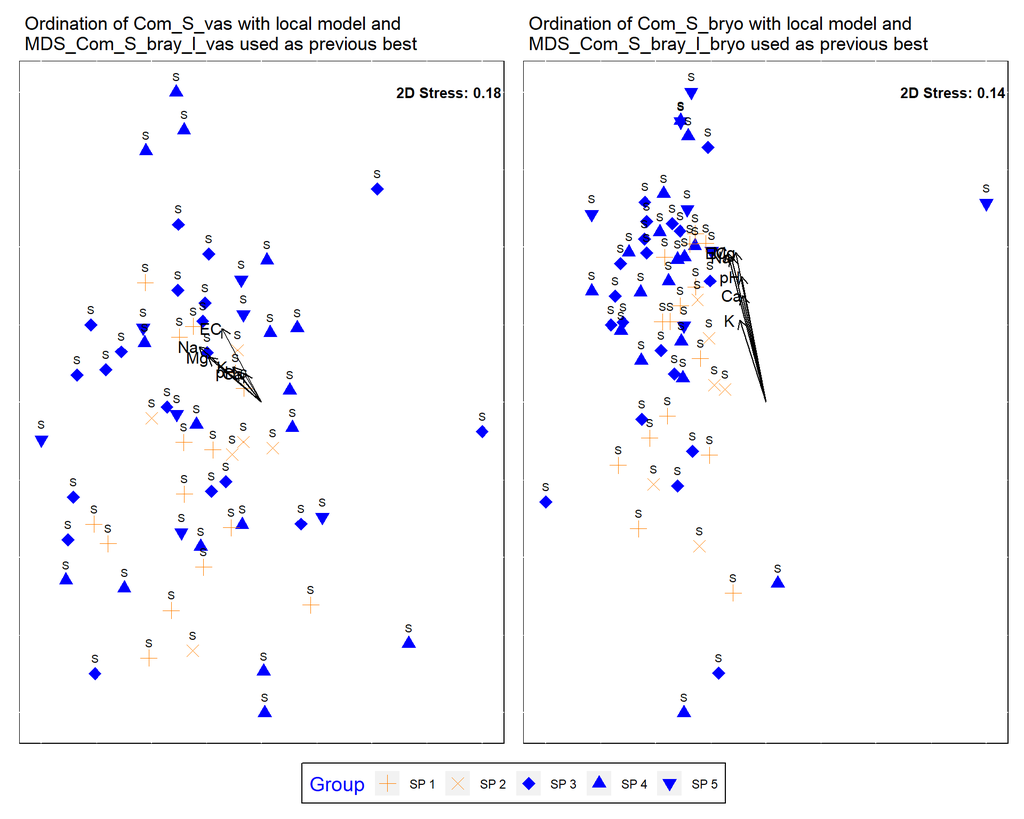

```r
set.seed(4153)


Com_S_bryo <- Com_S[50:90] # String data set only containing bryophytes
Com_S_vas <- Com_S[1:49] # String data set only containing vascular plants



# Ordinations for Strings


  # Bryophytes

    MDS_Com_S_bray_l_bryo <- metaMDS(Com_S_bryo, distance = "bray", k=2, try = 25, autotransform = FALSE,trace=FALSE, model = "local")

    MDS_Com_S_bray_pb_l_bryo<-metaMDS(Com_S_bryo, previous.best=MDS_Com_S_bray_l_bryo,trace=FALSE, autotransform = FALSE, k=2, try = 25,
                                       model = "local", distance = "bray")



      # Creating Plot

         gg_S_bray_pb_l_bry <- Luis_gg_mds_env(NMDS= MDS_Com_S_bray_pb_l_bryo, Env = Env, Plot_group= Sp_vec,
                  colour_base = Col_base, shape_base= Pch_base,add_S_F = TRUE,
                  xlim = c(1,-1), ylim = c(1,-1),legend_position = "bottom")





  # Vascular plants


      MDS_Com_S_bray_l_vas <- metaMDS(Com_S_vas, distance = "bray", k=2, try = 25, autotransform = FALSE,trace=FALSE, model = "local")

      MDS_Com_S_bray_pb_l_vas<-metaMDS(Com_S_vas, previous.best=MDS_Com_S_bray_l_vas,trace=FALSE, autotransform = FALSE, k=2, try = 25,
                                       model = "local", distance = "bray")



      # Creating Plot
      gg_F_bray_pb_l_vas <- Luis_gg_mds_env(NMDS= MDS_Com_S_bray_pb_l_vas, Env = Env, Plot_group= Sp_vec,
                  colour_base = Col_base, shape_base= Pch_base,add_S_F = TRUE,
                           xlim = c(1,-1), ylim = c(1,-1),legend_position = "bottom")





# Ploting

gg_F_bray_pb_l_vas + gg_S_bray_pb_l_bry + plot_layout(guides = "collect") & theme(legend.position = "bottom")
```

Taking a look at the Strings the described pattern can not be seen. Only for the bryophytes we can still see a general orientation of SP1 and SP2 to the lower end of the ordination and thereby also the chemical vectors. Looking (below) at the fit to the environmental data we also see that the we only have significant vectors for the bryophytes, also underlining the idea that they generally are more tightly connected to the chemical water parameters. Vitt et al.. also mention that “In contrast to strings, plant species occurring in flarks exhibit much more fidelity to water chemistry conditions.” This was already shown before looking at the correlations.

```r
set.seed(4153)

# using env_output = "only" to only show the environmental output

  # for bryophytes

Luis_gg_mds_env(NMDS= MDS_Com_S_bray_pb_l_bryo, Env = Env, Env_output = "only")
```

```
##
## ***VECTORS
##
##       NMDS1    NMDS2     r2 Pr(>r)
## Ca  0.29331 -0.95602 0.0905  0.047 *
## K   0.40624 -0.91377 0.0583  0.155
## Mg  0.27378 -0.96179 0.1757  0.001 ***
## Na  0.31615 -0.94871 0.1695  0.001 ***
## pH  0.26407 -0.96450 0.1232  0.016 *
## EC  0.34109 -0.94003 0.1829  0.001 ***
## ---
## Signif. codes:  0 '***' 0.001 '**' 0.01 '*' 0.05 '.' 0.1 ' ' 1
## Permutation: free
## Number of permutations: 999
```

```r
  # for vascular plants

Luis_gg_mds_env(NMDS= MDS_Com_S_bray_pb_l_vas, Env = Env, Env_output = "only")
```

```
##
## ***VECTORS
##
##       NMDS1    NMDS2     r2 Pr(>r)
## Ca  0.65659 -0.75425 0.0108  0.729
## K   0.75254 -0.65854 0.0211  0.538
## Mg  0.85622 -0.51661 0.0558  0.176
## Na  0.84496 -0.53483 0.0784  0.080 .
## pH  0.73799 -0.67481 0.0154  0.640
## EC  0.60271 -0.79796 0.0619  0.143
## ---
## Signif. codes:  0 '***' 0.001 '**' 0.01 '*' 0.05 '.' 0.1 ' ' 1
## Permutation: free
## Number of permutations: 999
```

# 12 Summary

The main focus of this work laid in assessing the difference in a global vs a local model and alternative indices vs. the Bray-Curtis index. While the authors used a global model and the Bray-Curtis index we found that using a local model as well as an alternative index can have benefits.

This work showed the value of assessing different modeling options. Once the Code is set up the amount of extra work to do so is negligible and it can improve the analysis and also the reliability of the results. This is especially true for cases in which the ordination is the central part of a scientific work.

The last part of the work underlined some of the ideas described by Vitt et al.. It also shows the value of further dividing a dataset to achieve a nuanced analysis and get further insight.

It would be interesting to explore the influence of further modeling options like the model options “linear” and “hybrid” and see if they allow for even better results. Also while testing different seeds I realized that the seed can have quite a big influence, especially for the envfit function. It would make sense to find a way to negate this influence.